# Comprehensive Ecological and Fisheries Data Analysis with aquats

Ataher Ali

2026-09-28

# 1 Introduction

The `aquats` package provides a robust, streamlined statistical and visualization toolkit tailored specifically for fisheries science, stock assessment workflows, and aquatic ecology. It bridges standard parametric models (ANOVA, ANCOVA, MANOVA) with advanced ecological tools, including non-linear morphometric regressions, generalized linear models (GLMs) for count data, customizable correlation heatmaps, and integrated Mantel test network linkages.

Load the package and required dependencies to begin:

```r
library(ggplot2)
library(dplyr)
library(emmeans)
library(multcomp)
library(MASS)
library(aquats)
```

## 1.1 Two-Sample Comparison (t-Test and F-Test)

### 1.1.1 Conceptual Framework

Comparing continuous ecological, biometric, or water-quality parameters between two distinct sample groups (e.g., Reference vs. Impacted sites, Upstream vs. Downstream) is a foundational statistical task. While Student’s classical $t$-test assumes equal population variances, ecological field data frequently violate this condition. The `compare_two_groups()` function automates variance screening via Fisher’s $F$-test, executes either Student’s or Welch’s $t$-test with Satterthwaite degrees of freedom, and packages diagnostics, effect sizes (Cohen’s $d$), and graphics into a single call.

### 1.1.2 Hypotheses and Variance Assumptions

The procedure simultaneously tests: 1. **Variance Homogeneity (Fisher’s $F$-test):**
$$H_0: \sigma_1^2 = \sigma_2^2 \quad \text{vs.}
\quad H_1: \sigma_1^2 \neq \sigma_2^2$$
2. **Mean Equality ($t$-test):**
$$H_0: \mu_1 = \mu_2 \quad \text{vs.} \quad H_1:
\mu_1 \neq \mu_2$$
When `var_equal = "auto"`, Welch’s correction is adopted automatically if the $F$-test rejects homoscedasticity ($p < 0.05$).

### 1.1.3 In-Vignette Data Generation

We simulate dissolved oxygen (DO, $\text{mg}\cdot\text{L}^{-1}$) monitoring records across two river stations exhibiting unequal variances:

```r
set.seed(42)
river_survey <- data.frame(
  Station = factor(rep(c("Upstream", "Downstream"), each = 25)),
  DO_mgL  = c(rnorm(25, mean = 7.8, sd = 0.55), rnorm(25, mean = 6.2, sd = 1.15))
)
```

### 1.1.4 Visualization Styles

#### 1.1.4.1 Style A: Publication Boxplot with Jitter

Default publication aesthetic displaying distribution medians, interquartile ranges, raw observations as jittered points, and an annotated significance bracket:

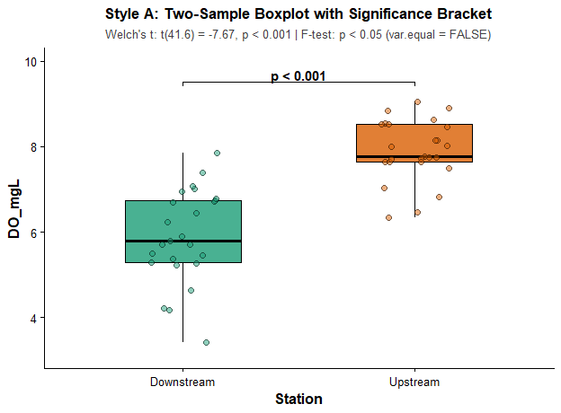

```r
res_box <- compare_two_groups(
  data         = river_survey,
  response_var = "DO_mgL",
  group_var    = "Station",
  var_equal    = "auto",
  plot_type    = "box",
  palette      = "Dark2",
  title        = "Style A: Two-Sample Boxplot with Significance Bracket"
)

print(res_box$Plot)
```

#### 1.1.4.2 Style B: Faceted / Density-Informed Violin Plot

Displays underlying data density distributions combined with an internal box-whisker geometry:

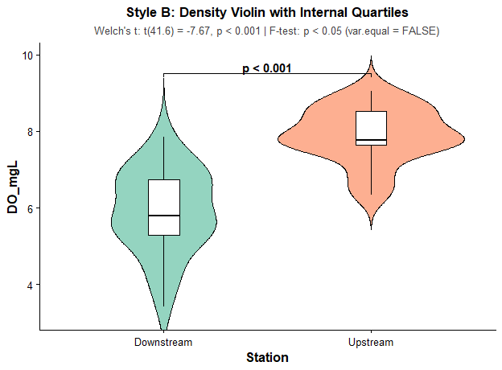

```r
res_violin <- compare_two_groups(
  data         = river_survey,
  response_var = "DO_mgL",
  group_var    = "Station",
  var_equal    = "auto",
  plot_type    = "violin",
  palette      = "Set2",
  title        = "Style B: Density Violin with Internal Quartiles"
)

print(res_violin$Plot)
```

#### 1.1.4.3 Style C: Minimalist Point and Mean-CI Error Bars

A clean point-and-interval layout emphasizing group means and 95% confidence intervals against jittered points:

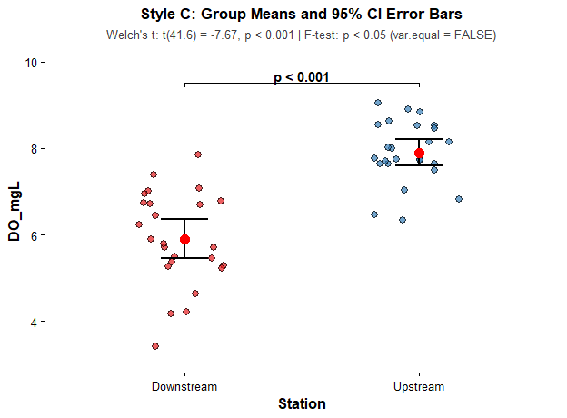

```r
res_jitter <- compare_two_groups(
  data         = river_survey,
  response_var = "DO_mgL",
  group_var    = "Station",
  var_equal    = "auto",
  plot_type    = "jitter",
  palette      = "Set1",
  title        = "Style C: Group Means and 95% CI Error Bars"
)

print(res_jitter$Plot)
```

### 1.1.5 Model Inspection and Normality Diagnostics

Review the automated assumption checks, formal test statistics, and effect sizes:

```r
# 1. Distribution Normality per group (Shapiro-Wilk)
knitr::kable(res_box$Normality_Test, caption = "Shapiro-Wilk Normality Evaluation")
```

Shapiro-Wilk Normality Evaluation

| Group | Statistic_W | p_value | Normal_05 |
| --- | --- | --- | --- |
| Downstream | 0.9716 | 0.6866 | Yes |
| Upstream | 0.9499 | 0.2495 | Yes |

```r
# 2. Fisher's F-test for Variance Equality
knitr::kable(res_box$F_Test, caption = "Fisher's F-Test for Homogeneity of Variances")
```

Fisher’s F-Test for Homogeneity of Variances

| Ratio_Var | F_Statistic | df_num | df_denom | p_value | Equal_Var_05 |
| --- | --- | --- | --- | --- | --- |
| 2.297 | 2.297 | 24 | 24 | 0.0468 | No |

```r
# 3. Two-Sample t-Test Results
knitr::kable(res_box$T_Test, caption = "t-Test Statistical Summary")
```

t-Test Statistical Summary

| Test_Type | Alternative | t_Statistic | df | p_value | CI_Lower | CI_Upper |
| --- | --- | --- | --- | --- | --- | --- |
| Welch Two Sample t-test | two.sided | -7.6683 | 41.57 | 0 | -2.5276 | -1.4741 |

```r
# 4. Group Descriptives and Cohen's d
knitr::kable(res_box$Summary_Table, caption = "Group Statistics and Standardized Effect Sizes")
```

Group Statistics and Standardized Effect Sizes

| Group | N | Mean | SD | SE | CI_Lower | CI_Upper | Mean_Diff | Cohen_d |
| --- | --- | --- | --- | --- | --- | --- | --- | --- |
| Downstream | 25 | 5.902 | 1.089 | 0.218 | 5.453 | 6.352 | -2.001 | 2.169 |
| Upstream | 25 | 7.903 | 0.719 | 0.144 | 7.607 | 8.200 | 2.001 | 2.169 |

## 1.2 Contingency Analysis and Goodness-of-Fit (Chi-Square Test)

### 1.2.1 Conceptual Framework

While analysis of variance and $t$-tests evaluate continuous measurements across groups, ecological and aquatic assessments frequently involve categorical observations (e.g., habitat substrate types, feeding guilds, species maturity status, or pollution compliance tiers). The `test_chisq()` function tests for significant associations between categorical factors (Test of Independence) or evaluates whether an observed frequency distribution conforms to theoretical expectations (Goodness-of-Fit).

### 1.2.2 Hypotheses and Effect Sizes

For a two-way contingency table ($r \times c$): 1. **Hypothesis of Independence:**
$$H_0: \text{Variable } X \text{ and Variable } Y
\text{ are independent}$$
$$H_1:
\text{Variable } X \text{ and Variable } Y \text{ are
associated}$$
2. **Standardized Residuals:** To determine which specific combinations drive a significant test result, standardized Pearson residuals ($r_{ij}$) are computed:
$$r_{ij} = \frac{O_{ij} - E_{ij}}{\sqrt{E_{ij} (1 -
p_{i\cdot}) (1 - p_{\cdot j})}}$$
Cells with $\vert{}r_{ij}\vert{} > 2.0$ indicate deviations significant at $\alpha = 0.05$. 3. **Strength of Association:** Quantified using **Cramér’s $V$**:
$$V = \sqrt{\frac{\chi^2}{N \cdot \min(r - 1,
c - 1)}}$$

### 1.2.3 In-Vignette Data Generation

We simulate fish maturity status across three sampling river reaches:

```r
set.seed(42)
fish_maturity <- data.frame(
  Reach = factor(rep(c("Upstream", "Midstream", "Estuary"), times = c(60, 70, 70))),
  Maturity = factor(c(
    sample(c("Immature", "Maturing", "Spent"), 60, replace = TRUE, prob = c(0.60, 0.30, 0.10)),
    sample(c("Immature", "Maturing", "Spent"), 70, replace = TRUE, prob = c(0.35, 0.45, 0.20)),
    sample(c("Immature", "Maturing", "Spent"), 70, replace = TRUE, prob = c(0.15, 0.35, 0.50))
  ))
)
```

### 1.2.4 Visualization Styles

#### 1.2.4.1 Style A: 100% Stacked Proportion Bar Chart

Displays the relative conditional percentage breakdown of categories across groups:

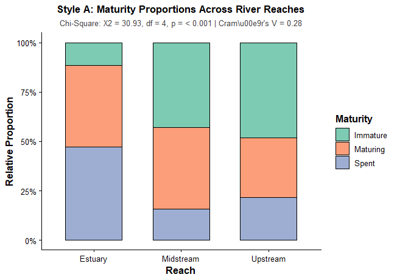

```r
res_stacked <- test_chisq(
  data      = fish_maturity,
  x         = "Reach",
  y         = "Maturity",
  plot_type = "stacked",
  palette   = "Set2",
  title     = "Style A: Maturity Proportions Across River Reaches"
)

print(res_stacked$Plot)
```

#### 1.2.4.2 Style B: Dodged Absolute Count Bar Chart

Displays raw sample counts side-by-side:

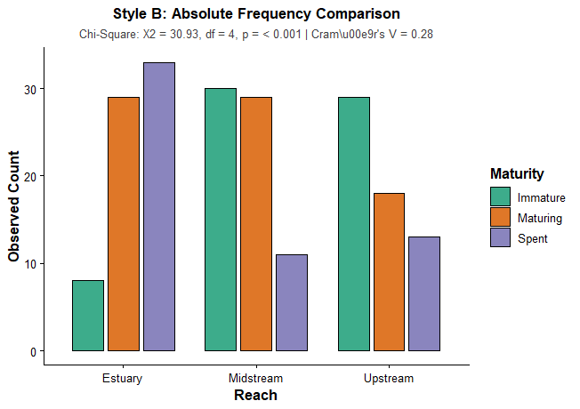

```r
res_dodged <- test_chisq(
  data      = fish_maturity,
  x         = "Reach",
  y         = "Maturity",
  plot_type = "dodged",
  palette   = "Dark2",
  title     = "Style B: Absolute Frequency Comparison"
)

print(res_dodged$Plot)
```

### 1.2.5 Model Inspection and Residual Diagnostics

Review test statistics, expected cell frequencies, and standardized residuals:

```r
# 1. Statistical Test Summary and Effect Size (Cramér's V)
knitr::kable(res_stacked$Chi_Square_Test, caption = "Chi-Square Test Summary and Association Strength")
```

Chi-Square Test Summary and Association Strength

| Test_Type | Chi_Square | df | p_value | Cramers_V | Phi |
| --- | --- | --- | --- | --- | --- |
| Pearson’s Chi-squared test | 30.9278 | 4 | 0 | 0.2781 | NA |

```r
# 2. Observed Contingency Table
knitr::kable(res_stacked$Observed_Counts, caption = "Observed Cell Frequencies")
```

Observed Cell Frequencies

| Reach | Immature | Maturing | Spent | Total |
| --- | --- | --- | --- | --- |
| Estuary | 8 | 29 | 33 | 70 |
| Midstream | 30 | 29 | 11 | 70 |
| Upstream | 29 | 18 | 13 | 60 |
| Total | 67 | 76 | 57 | 200 |

```r
# 3. Expected Cell Frequencies
knitr::kable(res_stacked$Expected_Counts, caption = "Expected Frequencies Under Independence")
```

Expected Frequencies Under Independence

| Reach | Immature | Maturing | Spent |
| --- | --- | --- | --- |
| Estuary | 23.45 | 26.6 | 19.95 |
| Midstream | 23.45 | 26.6 | 19.95 |
| Upstream | 20.10 | 22.8 | 17.10 |

```r
# 4. Standardized Pearson Residuals (|r| > 2 denotes significant deviation)
knitr::kable(res_stacked$Standardized_Residuals, caption = "Standardized Pearson Residuals")
```

Standardized Pearson Residuals

| Reach | Var1 | Var2 | Freq |
| --- | --- | --- | --- |
| 1 | Estuary | Immature | -4.853 |
| 2 | Midstream | Immature | 2.057 |
| 3 | Upstream | Immature | 2.910 |
| 4 | Estuary | Maturing | 0.733 |
| 5 | Midstream | Maturing | 0.733 |
| 6 | Upstream | Maturing | -1.526 |
| 7 | Estuary | Spent | 4.286 |
| 8 | Midstream | Spent | -2.939 |
| 9 | Upstream | Spent | -1.401 |

> *While the Chi-Square test evaluates associations among discrete frequency classes, comparing continuous metric responses across three or more treatment groups requires partitioning continuous variance, addressed in the next section.*

## 1.3 One-Way Analysis of Variance (ANOVA)

The `one_way_anova()` function provides an end-to-end analytical and graphical pipeline for evaluating differences in a continuous response variable across levels of a single categorical factor. In aquatic and fisheries research, this is commonly employed to compare water quality parameters across sampling stations, fish morphometric indices across river reaches, or nutrient concentrations across seasons.

The function handles defensive data cleaning, model fitting, computation of global F-tests, extraction of Estimated Marginal Means (EMMs), pairwise post-hoc contrasts with compact letter displays (CLD), and automated generation of publication-ready ggplot2 figures.

### 1.3.1 Conceptual Framework and Statistical Formulation

A classical fixed-effects One-Way ANOVA partitions the total variance in the response variable into between-group (explained) variance and within-group (unexplained error) variance:

$$y_{ij} = \mu + \alpha_i +
\varepsilon_{ij}$$

where: - $y_{ij}$ represents the $j$-th observation from the $i$-th treatment or habitat group ($i = 1, 2, \dots, k$; $j = 1, 2, \dots, n_i$), - $\mu$ represents the grand population mean, - $\alpha_i = \mu_i - \mu$ is the differential effect associated with group $i$, subject to the constraint $\sum n_i \alpha_i = 0$, - $\varepsilon_{ij} \overset{\text{i.i.d.}}{\sim} \mathcal{N}(0, \sigma^2)$ represents random residual error.

#### 1.3.1.1 Hypotheses and Test Statistics

The omnibus null hypothesis states that all group means are identical:

$$H_0: \mu_1 = \mu_2 = \dots =
\mu_k$$

$$H_1: \text{At least one group mean
differs from the others.}$$

The hypothesis is evaluated using the F-statistic:

$$F =
\frac{\text{MS}_{\text{between}}}{\text{MS}_{\text{within}}} =
\frac{\text{SS}_{\text{between}} / (k - 1)}{\text{SS}_{\text{within}} /
(N - k)}$$

When $H_0$ is rejected ($p < 0.05$), pairwise differences are resolved using Tukey’s Honest Significant Difference (HSD) test:

$$q = \frac{\bar{y}_i -
\bar{y}_j}{\sqrt{\frac{\text{MS}_{\text{within}}}{2} \left(\frac{1}{n_i}
+ \frac{1}{n_j}\right)}}$$

Groups sharing the same letter in the Compact Letter Display (CLD) are not statistically distinguishable at the specified significance threshold ($\alpha = 0.05$).

### 1.3.2 In-Vignette Data Generation

To illustrate the functionality, we simulate a standard riverine biomonitoring dataset evaluating Dissolved Oxygen (DO, mg/L) across three river zones: `Upper Basin` (forested reference), `Mid Reach` (agricultural run-off), and `Lower Estuary` (downstream industrial/tidal influence).

```r
set.seed(101)
n_obs <- 30

do_survey <- data.frame(
  Zone = factor(
    rep(c("Upper Basin", "Mid Reach", "Lower Estuary"), each = n_obs),
    levels = c("Upper Basin", "Mid Reach", "Lower Estuary")
  ),
  DO_mgL = c(
    rnorm(n_obs, mean = 8.50, sd = 0.45),
    rnorm(n_obs, mean = 6.80, sd = 0.55),
    rnorm(n_obs, mean = 4.90, sd = 0.60)
  )
)

head(do_survey, 6)
```

```
#>          Zone   DO_mgL
#> 1 Upper Basin 8.353284
#> 2 Upper Basin 8.748608
#> 3 Upper Basin 8.196275
#> 4 Upper Basin 8.596462
#> 5 Upper Basin 8.639846
#> 6 Upper Basin 9.028285
```

### 1.3.3 Visualization Styles

The `one_way_anova()` function supports multiple layout types depending on reporting requirements.

#### 1.3.3.1 Style A: Publication Boxplot with Jitter and Mean Marker (Default)

This style shows median lines, interquartile ranges, raw sample distributions via jittered points, and group means displayed as diamonds (`show_mean = TRUE`). Tukey post-hoc letters are automatically placed above each group distribution:

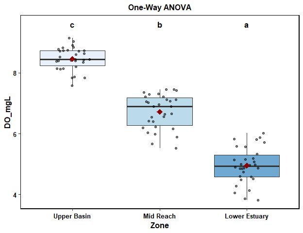

```r
res_box <- one_way_anova(
  data           = do_survey,
  factor_var     = "Zone",
  numeric_var    = "DO_mgL",
  plot_type      = "boxplot",
  add_jitter     = TRUE,
  show_mean      = TRUE,
  mean_color     = "darkred",
  sig_display    = "letters",
  color_palette  = "Blues"
)

res_box$Plot
```

#### 1.3.3.2 Style B: Grouped Barplot with Standard Error Bars (Mean ± SE)

For aquaculture trials or fisheries management reports, `plot_type = "barplot"` aggregates observations to their mean and attaches directional error bars (`error_type = "se"` or `error_type = "sd"`):

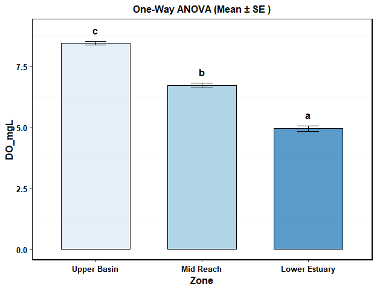

```r
res_bar <- one_way_anova(
  data           = do_survey,
  factor_var     = "Zone",
  numeric_var    = "DO_mgL",
  plot_type      = "barplot",
  error_type     = "se",
  sig_display    = "letters",
  color_palette  = "Blues"
)

res_bar$Plot
```

#### 1.3.3.3 Style C: Minimalist Point-Range Geometry

`plot_type = "pointrange"` provides a clean, modern alternative for comparing group means without column bars:

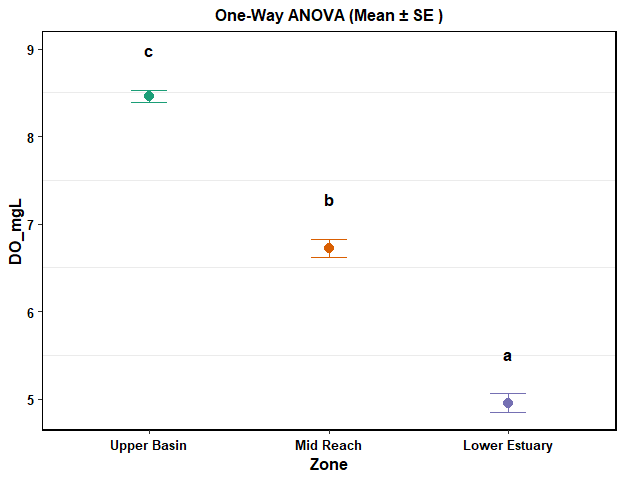

```r
res_point <- one_way_anova(
  data           = do_survey,
  factor_var     = "Zone",
  numeric_var    = "DO_mgL",
  plot_type      = "pointrange",
  error_type     = "se",
  sig_display    = "letters",
  color_palette  = "Dark2"
)

res_point$Plot
```

### 1.3.4 Model Inspection and Numerical Summaries

The function returns a comprehensive list containing the underlying ANOVA model, post-hoc pairwise comparisons, Estimated Marginal Means, and a summary statistics table:

```r
# Global ANOVA Table (F-statistic and p-value)
res_box$ANOVA_Summary
```

```
#>             Df Sum Sq Mean Sq F value Pr(>F)
#> Zone         2 184.71   92.36   339.9 <2e-16 ***
#> Residuals   87  23.64    0.27
#> ---
#> Signif. codes:  0 '***' 0.001 '**' 0.01 '*' 0.05 '.' 0.1 ' ' 1
```

```r
# Pairwise Tukey HSD Differences
res_box$TukeyHSD
```

```
#>   Tukey multiple comparisons of means
#>     95% family-wise confidence level
#>
#> Fit: stats::aov(formula = formula_str, data = clean_data)
#>
#> $Zone
#>                                diff       lwr       upr p adj
#> Mid Reach-Upper Basin     -1.740017 -2.060938 -1.419097     0
#> Lower Estuary-Upper Basin -3.509114 -3.830034 -3.188193     0
#> Lower Estuary-Mid Reach   -1.769096 -2.090017 -1.448176     0
```

```r
# Estimated Marginal Means (EMMs)
res_box$EMMs
```

```
#>  Zone          emmean     SE df lower.CL upper.CL
#>  Upper Basin     8.46 0.0952 87     8.27     8.65
#>  Mid Reach       6.72 0.0952 87     6.53     6.91
#>  Lower Estuary   4.95 0.0952 87     4.76     5.14
#>
#> Confidence level used: 0.95
```

```r
# Computed Summary Statistics Table
res_box$Summary_Table
```

```
#> # A tibble: 3 × 6
#>   Zone          mean_val sd_val se_val error_margin upper_limit
#>   <fct>            <dbl>  <dbl>  <dbl>        <dbl>       <dbl>
#> 1 Upper Basin       8.46  0.376 0.0686       0.0686        8.53
#> 2 Mid Reach         6.72  0.564 0.103        0.103         6.83
#> 3 Lower Estuary     4.95  0.596 0.109        0.109         5.06
```

## 1.4 Two-Way Analysis of Variance (ANOVA)

The `two_way_anova()` function performs factorial analysis of variance to simultaneously test the main effects of two categorical factors as well as their multiplicative interaction on a continuous aquatic response variable. In fisheries biology and aquatic ecology, factorial designs are standard practice for assessing seasonal variation across river basins, depth profiles across salinity gradients, or growth performance across diet and temperature treatments.

The function handles automated missing value filtering, model parameter estimation, computation of interaction sum-of-squares, post-hoc contrast grouping (via Estimated Marginal Means and Tukey’s HSD), and renders both grouped interaction plots and faceted sub-panel displays.

### 1.4.1 Conceptual Framework and Statistical Formulation

A classical fixed-effects balanced or unbalanced Two-Way ANOVA models the continuous response $y_{ijk}$ as:

$$y_{ijk} = \mu + \alpha_i + \beta_j +
(\alpha\beta)_{ij} + \varepsilon_{ijk}$$

where: - $y_{ijk}$ is the $k$-th replicate observation within level $i$ of Factor A and level $j$ of Factor B ($i = 1, \dots, a$; $j = 1, \dots, b$; $k = 1, \dots, n_{ij}$), - $\mu$ is the overall population grand mean, - $\alpha_i$ is the main effect of Factor A, subject to the identifiability constraint $\sum n_i \alpha_i = 0$, - $\beta_j$ is the main effect of Factor B, subject to the identifiability constraint $\sum n_j \beta_j = 0$, - $(\alpha\beta)_{ij}$ represents the interaction term capturing non-additive synergies or antagonisms between factors, - $\varepsilon_{ijk} \overset{\text{i.i.d.}}{\sim} \mathcal{N}(0, \sigma^2)$ is the random error term.

#### 1.4.1.1 Hypotheses and Variance Partitioning

The test partitions the total sum of squares ($\text{SS}_{\text{Total}}$) into orthogonal components:

$$\text{SS}_{\text{Total}} = \text{SS}_{A}
+ \text{SS}_{B} + \text{SS}_{AB} +
\text{SS}_{\text{Residual}}$$

The three core hypotheses evaluated by the model are:

1. Main Effect of Factor A:
   $$H_0^{(A)}:
   \alpha_1 = \dots = \alpha_a = 0 \quad \text{vs.} \quad F_A =
   \frac{\text{MS}_A}{\text{MS}_{\text{Residual}}}$$
2. Main Effect of Factor B:
   $$H_0^{(B)}:
   \beta_1 = \dots = \beta_b = 0 \quad \text{vs.} \quad F_B =
   \frac{\text{MS}_B}{\text{MS}_{\text{Residual}}}$$
3. Interaction Effect ($A \times B$):
   $$H_0^{(AB)}: (\alpha\beta)_{11}
   = \dots = (\alpha\beta)_{ab} = 0 \quad \text{vs.} \quad F_{AB} =
   \frac{\text{MS}_{AB}}{\text{MS}_{\text{Residual}}}$$

If the interaction effect is statistically significant ($p < 0.05$), main effects cannot be interpreted in isolation, and post-hoc pairwise contrasts are computed across the joint interaction levels using Estimated Marginal Means (EMMs).

### 1.4.2 In-Vignette Data Generation

We simulate a biomonitoring dataset evaluating fish condition factor ($K$) across three river basins (`Upper`, `Central`, `Lower`) sampled over two distinct hydrological periods (`Wet Season` vs `Dry Season`):

```r
set.seed(42)
n_reps <- 15

basins <- c("Upper Reach", "Central Basin", "Lower Estuary")
seasons <- c("Wet Season", "Dry Season")

fish_condition <- data.frame(
  Basin = factor(rep(rep(basins, each = n_reps), times = 2), levels = basins),
  Season = factor(rep(seasons, each = n_reps * length(basins)), levels = seasons),
  Condition_Factor = c(
    # Wet Season: Upper, Central, Lower
    rnorm(n_reps, mean = 1.35, sd = 0.08),
    rnorm(n_reps, mean = 1.18, sd = 0.09),
    rnorm(n_reps, mean = 1.05, sd = 0.10),
    # Dry Season: Upper, Central, Lower
    rnorm(n_reps, mean = 1.20, sd = 0.07),
    rnorm(n_reps, mean = 0.98, sd = 0.08),
    rnorm(n_reps, mean = 0.82, sd = 0.09)
  )
)

head(fish_condition, 6)
```

```
#>         Basin     Season Condition_Factor
#> 1 Upper Reach Wet Season         1.459677
#> 2 Upper Reach Wet Season         1.304824
#> 3 Upper Reach Wet Season         1.379050
#> 4 Upper Reach Wet Season         1.400629
#> 5 Upper Reach Wet Season         1.382341
#> 6 Upper Reach Wet Season         1.341510
```

### 1.4.3 Visualization Styles

The `two_way_anova()` function renders both grouped interaction plots (dodged) and faceted sub-panel displays across all standard geometries.

#### 1.4.3.1 Style A: Dodged Boxplot with Interaction Letters (Default)

This style groups the primary factor along the x-axis, using color fill to contrast the secondary factor side-by-side with raw sample jitters and mean indicators:

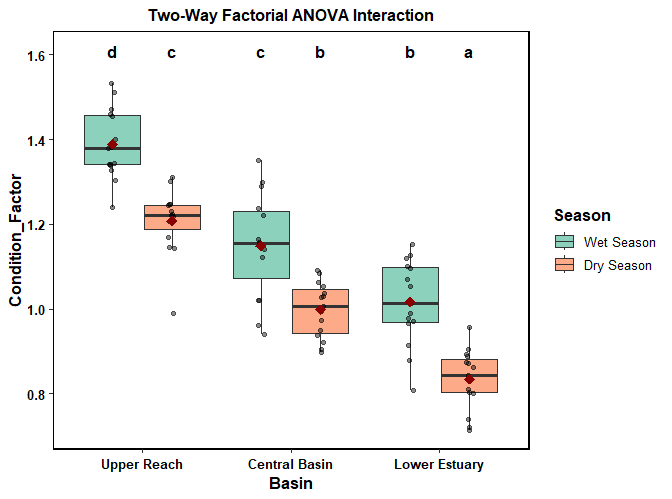

```r
res_two_box <- two_way_anova(
  data           = fish_condition,
  factor1_var    = "Basin",
  factor2_var    = "Season",
  numeric_var    = "Condition_Factor",
  plot_type      = "boxplot",
  add_jitter     = TRUE,
  show_mean      = TRUE,
  mean_color     = "darkred",
  color_palette  = "Set2"
)

res_two_box$Plot
```

#### 1.4.3.2 Style B: Faceted Barplot with Standard Error Bars (Mean ± SE)

By specifying `facet_var = "Season"`, the visualization cleanly segments the interaction into independent panels, preventing crowded error bars and overlapping categories:

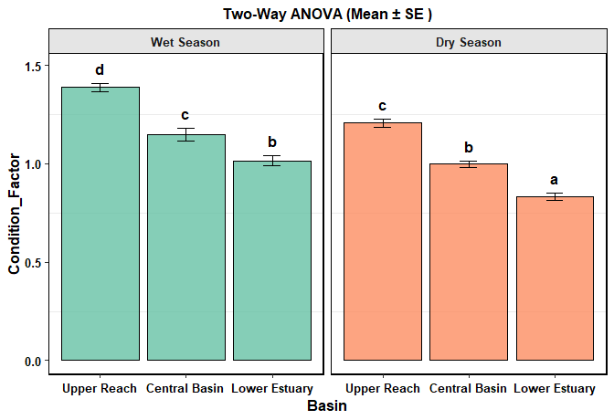

```r
res_two_bar <- two_way_anova(
  data           = fish_condition,
  factor1_var    = "Basin",
  factor2_var    = "Season",
  numeric_var    = "Condition_Factor",
  facet_var      = "Season",
  plot_type      = "barplot",
  error_type     = "se",
  color_palette  = "Set2"
)

res_two_bar$Plot
```

#### 1.4.3.3 Style C: Minimalist Point-Range Interaction

The point-range display plots mean coordinates and directional standard error bars, making it straightforward to inspect interaction divergence between levels:

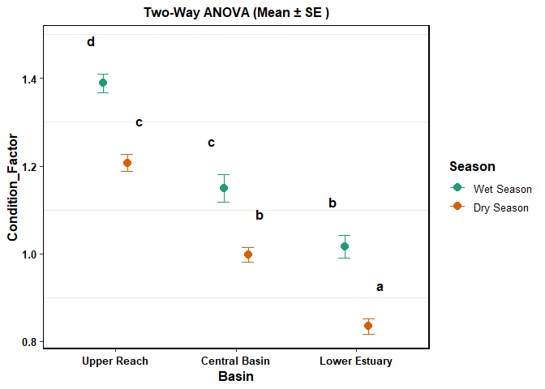

```r
res_two_point <- two_way_anova(
  data           = fish_condition,
  factor1_var    = "Basin",
  factor2_var    = "Season",
  numeric_var    = "Condition_Factor",
  plot_type      = "pointrange",
  error_type     = "se",
  color_palette  = "Dark2"
)

res_two_point$Plot
```

### 1.4.4 Model Inspection and Numerical Summaries

The function returns the comprehensive ANOVA table showing degrees of freedom, sum-of-squares, mean-squares, $F$-values, and $p$-values for both main factors and their interaction:

```r
# Factorial ANOVA Table (Main effects and Basin:Season interaction)
res_two_box$ANOVA_Summary
```

```
#>              Df Sum Sq Mean Sq F value   Pr(>F)
#> Basin         2 2.1146  1.0573 136.277  < 2e-16 ***
#> Season        1 0.6614  0.6614  85.244 2.02e-14 ***
#> Basin:Season  2 0.0048  0.0024   0.312    0.733
#> Residuals    84 0.6517  0.0078
#> ---
#> Signif. codes:  0 '***' 0.001 '**' 0.01 '*' 0.05 '.' 0.1 ' ' 1
```

```r
# Post-hoc pairwise differences (Tukey HSD)
res_two_box$TukeyHSD
```

```
#>   Tukey multiple comparisons of means
#>     95% family-wise confidence level
#>
#> Fit: stats::aov(formula = formula_str, data = clean_data)
#>
#> $Basin
#>                                   diff        lwr        upr p adj
#> Central Basin-Upper Reach   -0.2244000 -0.2786628 -0.1701371     0
#> Lower Estuary-Upper Reach   -0.3728956 -0.4271585 -0.3186328     0
#> Lower Estuary-Central Basin -0.1484957 -0.2027586 -0.0942328     0
#>
#> $Season
#>                            diff       lwr       upr p adj
#> Dry Season-Wet Season -0.171446 -0.208373 -0.134519     0
#>
#> $`Basin:Season`
#>                                                          diff         lwr
#> Central Basin:Wet Season-Upper Reach:Wet Season   -0.23997417 -0.33377867
#> Lower Estuary:Wet Season-Upper Reach:Wet Season   -0.37294488 -0.46674938
#> Upper Reach:Dry Season-Upper Reach:Wet Season     -0.18186162 -0.27566612
#> Central Basin:Dry Season-Upper Reach:Wet Season   -0.39068738 -0.48449188
#> Lower Estuary:Dry Season-Upper Reach:Wet Season   -0.55470804 -0.64851254
#> Lower Estuary:Wet Season-Central Basin:Wet Season -0.13297070 -0.22677521
#> Upper Reach:Dry Season-Central Basin:Wet Season    0.05811255 -0.03569195
#> Central Basin:Dry Season-Central Basin:Wet Season -0.15071321 -0.24451771
#> Lower Estuary:Dry Season-Central Basin:Wet Season -0.31473387 -0.40853837
#> Upper Reach:Dry Season-Lower Estuary:Wet Season    0.19108326  0.09727876
#> Central Basin:Dry Season-Lower Estuary:Wet Season -0.01774250 -0.11154700
#> Lower Estuary:Dry Season-Lower Estuary:Wet Season -0.18176316 -0.27556766
#> Central Basin:Dry Season-Upper Reach:Dry Season   -0.20882576 -0.30263026
#> Lower Estuary:Dry Season-Upper Reach:Dry Season   -0.37284642 -0.46665092
#> Lower Estuary:Dry Season-Central Basin:Dry Season -0.16402066 -0.25782516
#>                                                           upr     p adj
#> Central Basin:Wet Season-Upper Reach:Wet Season   -0.14616967 0.0000000
#> Lower Estuary:Wet Season-Upper Reach:Wet Season   -0.27914038 0.0000000
#> Upper Reach:Dry Season-Upper Reach:Wet Season     -0.08805712 0.0000031
#> Central Basin:Dry Season-Upper Reach:Wet Season   -0.29688288 0.0000000
#> Lower Estuary:Dry Season-Upper Reach:Wet Season   -0.46090354 0.0000000
#> Lower Estuary:Wet Season-Central Basin:Wet Season -0.03916620 0.0011495
#> Upper Reach:Dry Season-Central Basin:Wet Season    0.15191705 0.4670331
#> Central Basin:Dry Season-Central Basin:Wet Season -0.05690871 0.0001515
#> Lower Estuary:Dry Season-Central Basin:Wet Season -0.22092937 0.0000000
#> Upper Reach:Dry Season-Lower Estuary:Wet Season    0.28488776 0.0000009
#> Central Basin:Dry Season-Lower Estuary:Wet Season  0.07606200 0.9937363
#> Lower Estuary:Dry Season-Lower Estuary:Wet Season -0.08795866 0.0000031
#> Central Basin:Dry Season-Upper Reach:Dry Season   -0.11502126 0.0000001
#> Lower Estuary:Dry Season-Upper Reach:Dry Season   -0.27904192 0.0000000
#> Lower Estuary:Dry Season-Central Basin:Dry Season -0.07021616 0.0000301
```

```r
# Estimated Marginal Means with compact letter displays
res_two_box$EMMs
```

```
#>  Basin         Season     emmean     SE df lower.CL upper.CL
#>  Upper Reach   Wet Season  1.389 0.0227 84    1.344    1.434
#>  Central Basin Wet Season  1.149 0.0227 84    1.104    1.194
#>  Lower Estuary Wet Season  1.016 0.0227 84    0.971    1.061
#>  Upper Reach   Dry Season  1.207 0.0227 84    1.162    1.252
#>  Central Basin Dry Season  0.998 0.0227 84    0.953    1.043
#>  Lower Estuary Dry Season  0.834 0.0227 84    0.789    0.879
#>
#> Confidence level used: 0.95
```

```r
# Summary statistics table
res_two_box$Summary_Table
```

```
#> # A tibble: 6 × 7
#>   Basin         Season     mean_val sd_val se_val error_margin upper_limit
#>   <fct>         <fct>         <dbl>  <dbl>  <dbl>        <dbl>       <dbl>
#> 1 Upper Reach   Wet Season    1.39  0.0820 0.0212       0.0212       1.41
#> 2 Upper Reach   Dry Season    1.21  0.0762 0.0197       0.0197       1.23
#> 3 Central Basin Wet Season    1.15  0.122  0.0315       0.0315       1.18
#> 4 Central Basin Dry Season    0.998 0.0648 0.0167       0.0167       1.01
#> 5 Lower Estuary Wet Season    1.02  0.0997 0.0257       0.0257       1.04
#> 6 Lower Estuary Dry Season    0.834 0.0704 0.0182       0.0182       0.852
```

## 1.5 Three-Way Analysis of Variance (ANOVA)

The `three_way_anova()` function evaluates the simultaneous influence of three categorical factors and their complete interaction structure on a continuous aquatic response variable. In limnology, marine biology, and ecotoxicology, three-way factorial designs are commonly implemented to examine community or physiological responses across spatial zones, hydrological seasons, and water column depths simultaneously (e.g., Basin × Season × Depth).

The function automates factorial model fitting, calculation of main and interaction $F$-tests, derivation of Estimated Marginal Means across the complete three-way interaction lattice, post-hoc Tukey HSD letter grouping, and publication-ready faceted plotting.

### 1.5.1 Conceptual Framework and Statistical Formulation

The full three-way fixed-effects factorial model partitions the response variable $y_{ijkl}$ into three main factor effects, three two-way interaction terms, and one three-way interaction term:

$$y_{ijkl} = \mu + \alpha_i + \beta_j +
\gamma_k + (\alpha\beta)_{ij} + (\alpha\gamma)_{ik} + (\beta\gamma)_{jk}
+ (\alpha\beta\gamma)_{ijk} + \varepsilon_{ijkl}$$

where: - $y_{ijkl}$ represents the $l$-th observation under treatment combination $(i, j, k)$, - $\mu$ represents the grand population mean, - $\alpha_i$, $\beta_j$, and $\gamma_k$ represent the main effects of Factor 1 (e.g., Basin), Factor 2 (e.g., Season), and Factor 3 (e.g., Depth Layer), - $(\alpha\beta)_{ij}$, $(\alpha\gamma)_{ik}$, and $(\beta\gamma)_{jk}$ represent the two-way interaction effects, - $(\alpha\beta\gamma)_{ijk}$ represents the three-way interaction capturing higher-order non-linear dependencies across all factor levels, - $\varepsilon_{ijkl} \overset{\text{i.i.d.}}{\sim} \mathcal{N}(0, \sigma^2)$ is the random error term.

#### 1.5.1.1 Variance Partitioning and Hypotheses

Total variation is partitioned into seven distinct explained components alongside the residual error:

$$\text{SS}_{\text{Total}} = \text{SS}_A +
\text{SS}_B + \text{SS}_C + \text{SS}_{AB} + \text{SS}_{AC} +
\text{SS}_{BC} + \text{SS}_{ABC} +
\text{SS}_{\text{Residual}}$$

Each source of variation is tested against the residual mean square ($\text{MS}_{\text{Residual}}$). If the three-way interaction term $(\alpha\beta\gamma)_{ijk}$ is significant ($p < 0.05$), the response to Factor A depends simultaneously on the levels of both Factor B and Factor C. In this scenario, lower-order terms cannot be interpreted independently, and post-hoc contrasts are conducted across all joint treatment combinations.

### 1.5.2 In-Vignette Data Generation

We simulate a limnological biomonitoring dataset evaluating Phytoplankton Chlorophyll-a concentrations ($\mu\text{g/L}$) across two Lake Basins (`North Basin`, `South Basin`), two Seasons (`Pre-Monsoon`, `Post-Monsoon`), and two Depth Zones (`Epilimnion`, `Hypolimnion`):

```r
set.seed(303)
n_reps <- 10

basins  <- c("North Basin", "South Basin")
seasons <- c("Pre-Monsoon", "Post-Monsoon")
depths  <- c("Epilimnion", "Hypolimnion")

design_grid <- expand.grid(
  Basin  = basins,
  Season = seasons,
  Depth  = depths
)

chla_data <- do.call(rbind, lapply(seq_len(nrow(design_grid)), function(idx) {
  row_info <- design_grid[idx, ]

  # Baseline Chlorophyll-a dynamic
  base_val <- 14.0
  if (row_info$Basin == "South Basin") base_val <- base_val + 4.5
  if (row_info$Season == "Post-Monsoon") base_val <- base_val + 6.0
  if (row_info$Depth == "Hypolimnion") base_val <- base_val - 5.5

  # Three-way synergistic interaction in productive shallow waters
  if (row_info$Basin == "South Basin" && row_info$Season == "Post-Monsoon" && row_info$Depth == "Epilimnion") {
    base_val <- base_val + 8.0
  }

  data.frame(
    Basin    = factor(rep(row_info$Basin, n_reps), levels = basins),
    Season   = factor(rep(row_info$Season, n_reps), levels = seasons),
    Depth    = factor(rep(row_info$Depth, n_reps), levels = depths),
    Chla_ugL = rnorm(n_reps, mean = base_val, sd = 1.2)
  )
}))

head(chla_data, 6)
```

```
#>         Basin      Season      Depth Chla_ugL
#> 1 North Basin Pre-Monsoon Epilimnion 13.40367
#> 2 North Basin Pre-Monsoon Epilimnion 14.33461
#> 3 North Basin Pre-Monsoon Epilimnion 14.46136
#> 4 North Basin Pre-Monsoon Epilimnion 14.08230
#> 5 North Basin Pre-Monsoon Epilimnion 13.30615
#> 6 North Basin Pre-Monsoon Epilimnion 15.57667
```

### 1.5.3 Visualization Styles

The `three_way_anova()` function maps Factor 1 to the x-axis, Factor 2 to fill/color groupings, and uses `facet_wrap` to partition panels by Factor 3.

#### 1.5.3.1 Style A: Faceted Boxplot with Jitter and Means (Default)

Displays medians, IQRs, observation jitters, diamond mean markers, and three-way interaction letters:

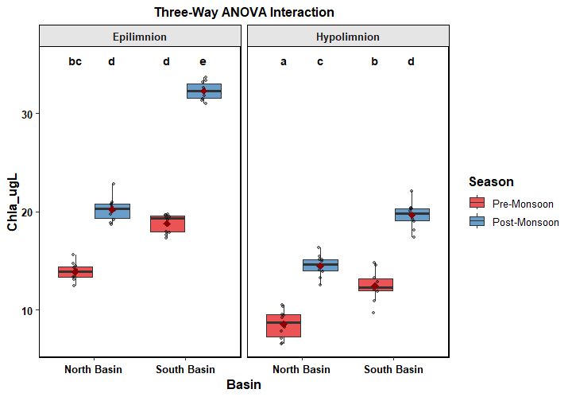

```r
res_three_box <- three_way_anova(
  data          = chla_data,
  factor1_var   = "Basin",
  factor2_var   = "Season",
  factor3_var   = "Depth",
  numeric_var   = "Chla_ugL",
  plot_type     = "boxplot",
  add_jitter    = TRUE,
  show_mean     = TRUE,
  mean_color    = "darkred",
  color_palette = "Set1"
)

res_three_box$Plot
```

#### 1.5.3.2 Style B: Faceted Barplot with Standard Error Bars (Mean ± SE)

Displays aggregated group means with directional standard error bars across faceted sub-panels:

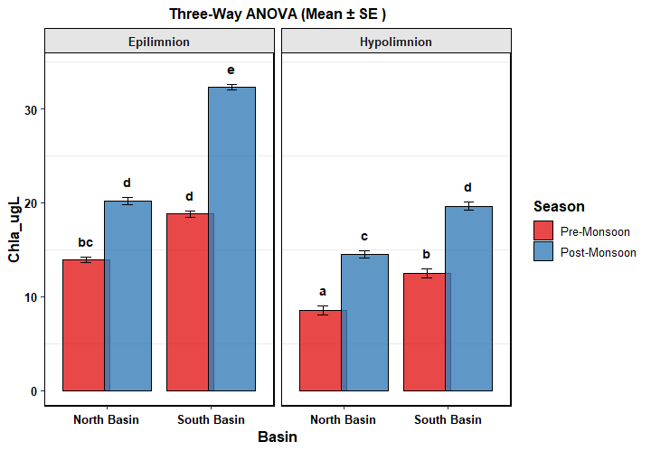

```r
res_three_bar <- three_way_anova(
  data          = chla_data,
  factor1_var   = "Basin",
  factor2_var   = "Season",
  factor3_var   = "Depth",
  numeric_var   = "Chla_ugL",
  plot_type     = "barplot",
  error_type    = "se",
  color_palette = "Set1"
)

res_three_bar$Plot
```

#### 1.5.3.3 Style C: Minimalist Faceted Point-Range Geometry

Presents mean values and error bounds across faceted panels:

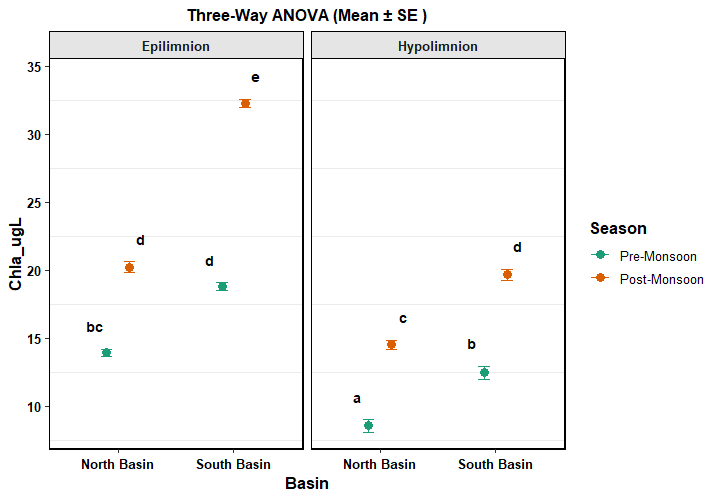

```r
res_three_point <- three_way_anova(
  data          = chla_data,
  factor1_var   = "Basin",
  factor2_var   = "Season",
  factor3_var   = "Depth",
  numeric_var   = "Chla_ugL",
  plot_type     = "pointrange",
  error_type    = "se",
  color_palette = "Dark2"
)

res_three_point$Plot
```

### 1.5.4 Model Inspection and Numerical Summaries

Extract the global three-way ANOVA summary, pairwise Tukey HSD differences, and Estimated Marginal Means:

```r
# Global Three-Way ANOVA Table (Main effects, 2-way, and 3-way interactions)
res_three_box$ANOVA_Summary
```

```
#>                    Df Sum Sq Mean Sq F value   Pr(>F)
#> Basin               1  842.8   842.8  588.35  < 2e-16 ***
#> Season              1 1355.0  1355.0  945.99  < 2e-16 ***
#> Depth               1 1127.1  1127.1  786.88  < 2e-16 ***
#> Basin:Season        1   88.7    88.7   61.95 2.67e-11 ***
#> Basin:Depth         1   77.7    77.7   54.27 2.32e-10 ***
#> Season:Depth        1   55.3    55.3   38.58 3.03e-08 ***
#> Basin:Season:Depth  1   44.3    44.3   30.90 4.33e-07 ***
#> Residuals          72  103.1     1.4
#> ---
#> Signif. codes:  0 '***' 0.001 '**' 0.01 '*' 0.05 '.' 0.1 ' ' 1
```

```r
# Post-hoc pairwise differences (Tukey HSD)
res_three_box$TukeyHSD
```

```
#>   Tukey multiple comparisons of means
#>     95% family-wise confidence level
#>
#> Fit: stats::aov(formula = formula_str, data = clean_data)
#>
#> $Basin
#>                            diff     lwr     upr p adj
#> South Basin-North Basin 6.49138 5.95789 7.02487     0
#>
#> $Season
#>                              diff      lwr      upr p adj
#> Post-Monsoon-Pre-Monsoon 8.231143 7.697653 8.764633     0
#>
#> $Depth
#>                             diff       lwr       upr p adj
#> Hypolimnion-Epilimnion -7.507095 -8.040585 -6.973605     0
#>
#> $`Basin:Season`
#>                                                        diff        lwr
#> South Basin:Pre-Monsoon-North Basin:Pre-Monsoon    4.384920  3.3895175
#> North Basin:Post-Monsoon-North Basin:Pre-Monsoon   6.124683  5.1292805
#> South Basin:Post-Monsoon-North Basin:Pre-Monsoon  14.722523 13.7271207
#> North Basin:Post-Monsoon-South Basin:Pre-Monsoon   1.739763  0.7443605
#> South Basin:Post-Monsoon-South Basin:Pre-Monsoon  10.337603  9.3422007
#> South Basin:Post-Monsoon-North Basin:Post-Monsoon  8.597840  7.6024377
#>                                                         upr     p adj
#> South Basin:Pre-Monsoon-North Basin:Pre-Monsoon    5.380323 0.0000000
#> North Basin:Post-Monsoon-North Basin:Pre-Monsoon   7.120086 0.0000000
#> South Basin:Post-Monsoon-North Basin:Pre-Monsoon  15.717926 0.0000000
#> North Basin:Post-Monsoon-South Basin:Pre-Monsoon   2.735166 0.0001037
#> South Basin:Post-Monsoon-South Basin:Pre-Monsoon  11.333006 0.0000000
#> South Basin:Post-Monsoon-North Basin:Post-Monsoon  9.593243 0.0000000
#>
#> $`Basin:Depth`
#>                                                       diff        lwr
#> South Basin:Epilimnion-North Basin:Epilimnion     8.462844   7.467441
#> North Basin:Hypolimnion-North Basin:Epilimnion   -5.535631  -6.531034
#> South Basin:Hypolimnion-North Basin:Epilimnion   -1.015715  -2.011117
#> North Basin:Hypolimnion-South Basin:Epilimnion  -13.998475 -14.993877
#> South Basin:Hypolimnion-South Basin:Epilimnion   -9.478558 -10.473961
```

[output cut: 127 more lines]

```
#> South Basin:Post-Monsoon:Epilimnion-North Basin:Post-Monsoon:Epilimnion   0.0000000
#> North Basin:Pre-Monsoon:Hypolimnion-North Basin:Post-Monsoon:Epilimnion   0.0000000
#> South Basin:Pre-Monsoon:Hypolimnion-North Basin:Post-Monsoon:Epilimnion   0.0000000
#> North Basin:Post-Monsoon:Hypolimnion-North Basin:Post-Monsoon:Epilimnion  0.0000000
#> South Basin:Post-Monsoon:Hypolimnion-North Basin:Post-Monsoon:Epilimnion  0.9614041
#> North Basin:Pre-Monsoon:Hypolimnion-South Basin:Post-Monsoon:Epilimnion   0.0000000
#> South Basin:Pre-Monsoon:Hypolimnion-South Basin:Post-Monsoon:Epilimnion   0.0000000
#> North Basin:Post-Monsoon:Hypolimnion-South Basin:Post-Monsoon:Epilimnion  0.0000000
#> South Basin:Post-Monsoon:Hypolimnion-South Basin:Post-Monsoon:Epilimnion  0.0000000
#> South Basin:Pre-Monsoon:Hypolimnion-North Basin:Pre-Monsoon:Hypolimnion   0.0000000
#> North Basin:Post-Monsoon:Hypolimnion-North Basin:Pre-Monsoon:Hypolimnion  0.0000000
#> South Basin:Post-Monsoon:Hypolimnion-North Basin:Pre-Monsoon:Hypolimnion  0.0000000
#> North Basin:Post-Monsoon:Hypolimnion-South Basin:Pre-Monsoon:Hypolimnion  0.0063183
#> South Basin:Post-Monsoon:Hypolimnion-South Basin:Pre-Monsoon:Hypolimnion  0.0000000
#> South Basin:Post-Monsoon:Hypolimnion-North Basin:Post-Monsoon:Hypolimnion 0.0000000
```

```r
# Estimated Marginal Means across the 3-way interaction grid
res_three_box$EMMs
```

```
#>  Basin       Season       Depth       emmean    SE df lower.CL upper.CL
#>  North Basin Pre-Monsoon  Epilimnion   13.92 0.378 72    13.17    14.68
#>  South Basin Pre-Monsoon  Epilimnion   18.79 0.378 72    18.04    19.55
#>  North Basin Post-Monsoon Epilimnion   20.22 0.378 72    19.47    20.98
#>  South Basin Post-Monsoon Epilimnion   32.28 0.378 72    31.52    33.03
#>  North Basin Pre-Monsoon  Hypolimnion   8.56 0.378 72     7.81     9.32
#>  South Basin Pre-Monsoon  Hypolimnion  12.46 0.378 72    11.71    13.22
#>  North Basin Post-Monsoon Hypolimnion  14.51 0.378 72    13.76    15.27
#>  South Basin Post-Monsoon Hypolimnion  19.65 0.378 72    18.90    20.41
#>
#> Confidence level used: 0.95
```

```r
# Aggregated summary statistics
res_three_box$Summary_Table
```

```
#> # A tibble: 8 × 8
#>   Basin       Season       Depth mean_val sd_val se_val error_margin upper_limit
#>   <fct>       <fct>        <fct>    <dbl>  <dbl>  <dbl>        <dbl>       <dbl>
#> 1 North Basin Pre-Monsoon  Epil…    13.9   0.898  0.284        0.284       14.2
#> 2 North Basin Pre-Monsoon  Hypo…     8.56  1.47   0.466        0.466        9.03
#> 3 North Basin Post-Monsoon Epil…    20.2   1.21   0.384        0.384       20.6
#> 4 North Basin Post-Monsoon Hypo…    14.5   1.11   0.352        0.352       14.9
#> 5 South Basin Pre-Monsoon  Epil…    18.8   0.964  0.305        0.305       19.1
#> 6 South Basin Pre-Monsoon  Hypo…    12.5   1.52   0.481        0.481       12.9
#> 7 South Basin Post-Monsoon Epil…    32.3   0.910  0.288        0.288       32.6
#> 8 South Basin Post-Monsoon Hypo…    19.7   1.31   0.413        0.413       20.1
```

## 1.6 Analysis of Covariance (ANCOVA)

The `ancova_analysis()` function combines linear regression and Analysis of Variance to test for differences in a continuous response variable across categorical treatment groups while statistically controlling for a continuous nuisance variable (covariate). In fisheries stock assessment and aquatic ecology, ANCOVA is routinely used to compare fish weight across sampling locations while controlling for body length, or to compare metabolic excretion rates across diet formulations while controlling for individual biomass.

The function handles missing value removal, fits an additive general linear model, extracts the omnibus ANCOVA table, computes Estimated Marginal Means (EMMs) adjusted to the mean value of the covariate, and renders publication-quality scatter plots with parallel regression trend lines.

### 1.6.1 Conceptual Framework and Statistical Formulation

The additive fixed-effects ANCOVA model represents the response variable $y_{ij}$ as:

$$y_{ij} = \mu + \alpha_i + \beta (x_{ij}
- \bar{x}) + \varepsilon_{ij}$$

where: - $y_{ij}$ is the response observed for the $j$-th individual in group $i$ ($i = 1, \dots, k$; $j = 1, \dots, n_i$), - $\mu$ is the overall adjusted grand mean, - $\alpha_i$ is the categorical treatment effect of group $i$, subject to the constraint $\sum n_i \alpha_i = 0$, - $\beta$ is the common pooled regression slope relating the continuous covariate $x$ to response $y$, - $x_{ij}$ is the covariate value for individual $j$ in group $i$, centered around the grand covariate mean $\bar{x}$, - $\varepsilon_{ij} \overset{\text{i.i.d.}}{\sim} \mathcal{N}(0, \sigma^2)$ is the normally distributed random error term.

#### 1.6.1.1 Homogeneity of Slopes and Adjusted Means

A core assumption of additive ANCOVA is the homogeneity of regression slopes, meaning the relationship between the covariate ($x$) and the response ($y$) does not vary across factor levels ($\beta_1 = \beta_2 = \dots = \beta_k = \beta$).

When this assumption holds, the categorical factor effect evaluates whether the elevations (y-intercepts) of the parallel regression lines differ significantly:

$$H_0: \alpha_1 = \alpha_2 = \dots =
\alpha_k = 0$$
$$H_1: \text{At least
one group elevation differs.}$$

Because raw group means are confounded by variations in the covariate, `ancova_analysis()` computes Estimated Marginal Means (EMMs). The adjusted mean for group $i$ ($\hat{\mu}_i$) is evaluated at the grand mean of the covariate ($\bar{x}_{\bullet\bullet}$):

$$\hat{\mu}_i = \bar{y}_{i\bullet} -
\hat{\beta}(\bar{x}_{i\bullet} - \bar{x}_{\bullet\bullet})$$

### 1.6.2 In-Vignette Data Generation

We simulate a fisheries length-weight dataset evaluating somatic body weight ($\text{Weight}$, $\text{g}$) across three distinct aquatic habitats (`Estuary`, `River`, `Marine`) while controlling for continuous total body length ($\text{Length}$, $\text{cm}$):

```r
set.seed(2026)
n_per_habitat <- 35

habitats <- c("Estuary", "River", "Marine")

fish_growth <- do.call(rbind, lapply(habitats, function(hab) {
  # Generate continuous covariate: fish total length (cm)
  len <- runif(n_per_habitat, min = 12.0, max = 38.0)

  # Group elevation shifts (intercept differences)
  elevation_shift <- switch(hab,
    "Estuary" = -12.0,
    "River"   = -4.0,
    "Marine"  = 8.0
  )

  # Additive response: common slope (beta = 3.25) + habitat elevation + noise
  wt <- 3.25 * len + elevation_shift + rnorm(n_per_habitat, mean = 0, sd = 4.2)

  data.frame(
    Habitat = factor(rep(hab, n_per_habitat), levels = habitats),
    Length  = len,
    Weight  = wt
  )
}))

head(fish_growth, 6)
```

```
#>   Habitat   Length   Weight
#> 1 Estuary 30.16551 85.25238
#> 2 Estuary 26.46979 73.78666
#> 3 Estuary 15.64364 38.28039
#> 4 Estuary 19.42881 55.97057
#> 5 Estuary 26.43959 73.29607
#> 6 Estuary 12.65341 21.49277
```

### 1.6.3 Visualization Styles

`ancova_analysis()` plots the empirical observations alongside model-fitted regression lines. This preserves the parallel slopes of the additive model, avoiding the misleading non-parallel lines produced by unconstrained smoothers.

#### 1.6.3.1 Style A: Single-Panel Parallel Slopes Comparison (Default)

Presents all groups on a shared coordinate grid (`facet = FALSE`), allowing direct visual comparison of vertical line separations (elevation differences):

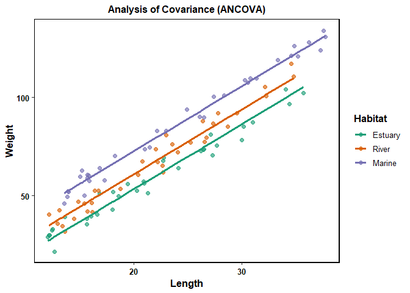

```r
res_ancova <- ancova_analysis(
  data          = fish_growth,
  response_var  = "Weight",
  factor_var    = "Habitat",
  covariate_var = "Length",
  facet         = FALSE,
  color_palette = "Dark2"
)

# Render publication plot
res_ancova$Plot
```

#### 1.6.3.2 Style B: Faceted Panel View

When working with dense datasets or multiple overlapping factor levels, setting `facet = TRUE` separates each group into its own panel using `facet_wrap`, while keeping the coordinate scales fixed for consistent comparison:

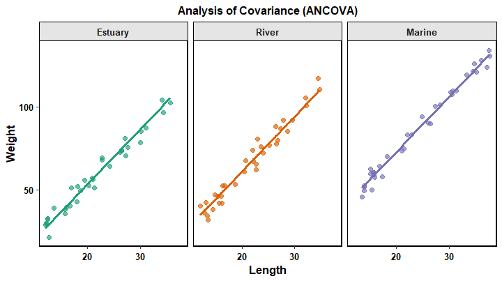

```r
res_ancova_facet <- ancova_analysis(
  data          = fish_growth,
  response_var  = "Weight",
  factor_var    = "Habitat",
  covariate_var = "Length",
  facet         = TRUE,
  color_palette = "Dark2"
)

res_ancova_facet$Plot
```

### 1.6.4 Model Inspection and Numerical Summaries

The returned list object provides the ANOVA table testing the covariate and categorical factor effects, as well as the covariate-adjusted Estimated Marginal Means:

```r
# 1. ANCOVA Table (Testing covariate and factor significance)
res_ancova$ANCOVA_Table
```

```
#> Analysis of Variance Table
#>
#> Response: Weight
#>            Df Sum Sq Mean Sq F value    Pr(>F)
#> Length      1  69814   69814 4111.69 < 2.2e-16 ***
#> Habitat     2   6473    3236  190.61 < 2.2e-16 ***
#> Residuals 101   1715      17
#> ---
#> Signif. codes:  0 '***' 0.001 '**' 0.01 '*' 0.05 '.' 0.1 ' ' 1
```

```r
# 2. Estimated Marginal Means (EMMs adjusted to mean Length)
res_ancova$Adjusted_Means
```

```
#>  Habitat emmean    SE  df lower.CL upper.CL
#>  Estuary   61.6 0.699 101     60.2     63.0
#>  River     69.2 0.698 101     67.8     70.6
#>  Marine    81.0 0.703 101     79.6     82.3
#>
#> Confidence level used: 0.95
```

## 1.7 Multivariate Analysis of Variance (MANOVA)

The `manova_analysis()` function extends analysis of variance to multi-response hypotheses, testing whether mean vectors of several correlated continuous variables differ across levels of a categorical grouping variable. In fisheries biology and aquatic ecology, MANOVA is commonly applied in morphometric stock discrimination (e.g., comparing head length, body depth, and caudal peduncle length simultaneously across river populations) or multi-metric water quality assessments (e.g., evaluating simultaneous variations in nitrates, phosphates, and ammonium across wetland sites).

The function conducts defensive data verification, fits the multivariate general linear model, evaluates omnibus significance using Pillai’s trace criterion, derives univariate ANOVA decompositions, and provides two distinct visualization geometries: faceted univariate trait boxplots and Canonical Discriminant Analysis (LDA) scatter plots with 95% confidence ellipses.

### 1.7.1 Conceptual Framework and Statistical Formulation

Let $\mathbf{y}_{ij} = [y_{ij1}, y_{ij2}, \dots, y_{ijp}]^T$ represent a $p$-dimensional vector of continuous response measurements recorded for the $j$-th specimen in treatment group $i$ ($i = 1, \dots, k$; $j = 1, \dots, n_i$). The one-way multivariate linear model is defined as:

$$\mathbf{y}_{ij} = \boldsymbol{\mu} +
\boldsymbol{\alpha}_i + \boldsymbol{\varepsilon}_{ij}$$

where: - $\boldsymbol{\mu} = [\mu_1, \dots, \mu_p]^T$ represents the grand centroid vector across all $p$ traits, - $\boldsymbol{\alpha}_i = [\alpha_{i1}, \dots, \alpha_{ip}]^T$ represents the differential group effect vector for group $i$, - $\boldsymbol{\varepsilon}_{ij} \overset{\text{i.i.d.}}{\sim} \mathcal{N}_p(\mathbf{0}, \boldsymbol{\Sigma})$ represents the multivariate normal random error vector with variance-covariance matrix $\boldsymbol{\Sigma}$.

#### 1.7.1.1 Hypothesis Testing and Test Statistics

The omnibus multivariate null hypothesis states that group centroids are identical across all $p$ dimensions:

$$H_0: \boldsymbol{\mu}_1 =
\boldsymbol{\mu}_2 = \dots = \boldsymbol{\mu}_k$$
$$H_1: \text{At least two group centroid vectors
differ.}$$

The total variance-covariance matrix is partitioned into the Between-Group Sum of Squares and Cross-Products matrix ($\mathbf{H}$) and the Within-Group (Error) Sum of Squares and Cross-Products matrix ($\mathbf{E}$):

$$\mathbf{H} = \sum_{i=1}^k n_i
(\bar{\mathbf{y}}_{i\bullet} -
\bar{\mathbf{y}}_{\bullet\bullet})(\bar{\mathbf{y}}_{i\bullet} -
\bar{\mathbf{y}}_{\bullet\bullet})^T$$

$$\mathbf{E} = \sum_{i=1}^k
\sum_{j=1}^{n_i} (\mathbf{y}_{ij} -
\bar{\mathbf{y}}_{i\bullet})(\mathbf{y}_{ij} -
\bar{\mathbf{y}}_{i\bullet})^T$$

While several test criteria exist (Wilks’ Lambda, Hotelling-Lawley trace, Roy’s largest root), `manova_analysis()` defaults to Pillai’s Trace ($V$) due to its robustness against departures from multivariate normality and moderate covariance heterogeneity:

$$V = \text{tr}\left[\mathbf{H}(\mathbf{H}
+ \mathbf{E})^{-1}\right] = \sum_{m=1}^s \frac{\lambda_m}{1 +
\lambda_m}$$

where $\lambda_m$ represents the eigenvalues of $\mathbf{E}^{-1}\mathbf{H}$, and $s = \min(p, k - 1)$. The statistic is converted to an approximate $F$-distribution to establish statistical significance.

### 1.7.2 In-Vignette Data Generation

We simulate a morphometric stock identification survey measuring four anatomical truss traits (Total Length `TL`, Head Length `HL`, Body Depth `BD`, and Caudal Width `CW` in cm) across three wild fish populations (`River_A`, `River_B`, and `River_C`):

```r
set.seed(505)
n_fish <- 25

populations <- c("River_A", "River_B", "River_C")

# Simulate multivariate normal morphometric data
morpho_data <- do.call(rbind, lapply(populations, function(pop) {
  # Baseline centroid shifts per population
  shift <- switch(pop,
    "River_A" = c(TL = 24.0, HL = 5.2, BD = 6.5, CW = 2.1),
    "River_B" = c(TL = 28.5, HL = 6.4, BD = 7.8, CW = 2.6),
    "River_C" = c(TL = 21.0, HL = 4.8, BD = 5.9, CW = 1.9)
  )

  data.frame(
    Population = factor(rep(pop, n_fish), levels = populations),
    TL = rnorm(n_fish, mean = shift["TL"], sd = 1.5),
    HL = rnorm(n_fish, mean = shift["HL"], sd = 0.4),
    BD = rnorm(n_fish, mean = shift["BD"], sd = 0.5),
    CW = rnorm(n_fish, mean = shift["CW"], sd = 0.2)
  )
}))

head(morpho_data, 6)
```

```
#>   Population       TL       HL       BD       CW
#> 1    River_A 22.31822 5.435375 5.605484 1.812157
#> 2    River_A 22.07691 5.041592 6.145151 1.972692
#> 3    River_A 20.94099 5.282860 5.595230 1.829734
#> 4    River_A 22.59340 5.254322 6.134524 2.257909
#> 5    River_A 23.23476 5.786759 6.319575 2.392531
#> 6    River_A 23.38073 4.793155 5.212262 1.967572
```

### 1.7.3 Visualization Styles

The `manova_analysis()` function provides two complementary visual perspectives: faceted univariate trait distributions and multivariate canonical ordination.

#### 1.7.3.1 Style A: Faceted Univariate Trait Boxplots (Default)

Decomposes the multivariate space into separate panels for each continuous trait, showing median values, interquartile ranges, and individual observation distributions:

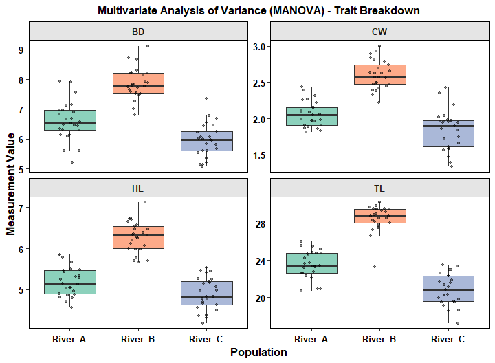

```r
res_manova_box <- manova_analysis(
  data           = morpho_data,
  response_vars  = c("TL", "HL", "BD", "CW"),
  factor_var     = "Population",
  plot_type      = "boxplot",
  color_palette  = "Set2"
)

# Render faceted traits
res_manova_box$Plot
```

#### 1.7.3.2 Style B: Canonical Discriminant Analysis (LDA) Ordination

Projects the multi-trait measurements into canonical discriminant space (Linear Discriminant axes `LD1` and `LD2`), displaying multivariate centroid separation and 95% group confidence ellipses:

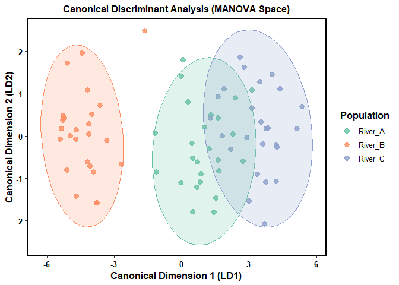

```r
res_manova_lda <- manova_analysis(
  data           = morpho_data,
  response_vars  = c("TL", "HL", "BD", "CW"),
  factor_var     = "Population",
  plot_type      = "lda",
  color_palette  = "Set2"
)

# Render canonical discriminant ordination
res_manova_lda$Plot
```

### 1.7.4 Model Inspection and Numerical Summaries

The returned list delivers both the global multivariate Pillai’s trace summary and the individual univariate ANOVA breakdowns:

```r
# 1. Omnibus MANOVA Summary (Pillai's Trace, F-approximation, p-value)
res_manova_box$MANOVA_Summary
```

```
#>            Df  Pillai approx F num Df den Df    Pr(>F)
#> Population  2 0.94978   15.826      8    140 < 2.2e-16 ***
#> Residuals  72
#> ---
#> Signif. codes:  0 '***' 0.001 '**' 0.01 '*' 0.05 '.' 0.1 ' ' 1
```

```r
# 2. Univariate ANOVA Breakdowns for Each Morphometric Trait
res_manova_box$Univariate_ANOVAs
```

```
#>  Response TL :
#>             Df Sum Sq Mean Sq F value    Pr(>F)
#> Population   2  755.7  377.85  162.71 < 2.2e-16 ***
#> Residuals   72  167.2    2.32
#> ---
#> Signif. codes:  0 '***' 0.001 '**' 0.01 '*' 0.05 '.' 0.1 ' ' 1
#>
#>  Response HL :
#>             Df Sum Sq Mean Sq F value    Pr(>F)
#> Population   2 26.439 13.2195  93.691 < 2.2e-16 ***
#> Residuals   72 10.159  0.1411
#> ---
#> Signif. codes:  0 '***' 0.001 '**' 0.01 '*' 0.05 '.' 0.1 ' ' 1
#>
#>  Response BD :
#>             Df Sum Sq Mean Sq F value    Pr(>F)
#> Population   2 47.020 23.5101  69.044 < 2.2e-16 ***
#> Residuals   72 24.517  0.3405
#> ---
#> Signif. codes:  0 '***' 0.001 '**' 0.01 '*' 0.05 '.' 0.1 ' ' 1
#>
#>  Response CW :
#>             Df Sum Sq Mean Sq F value    Pr(>F)
#> Population   2 7.6740   3.837  78.335 < 2.2e-16 ***
#> Residuals   72 3.5267   0.049
#> ---
#> Signif. codes:  0 '***' 0.001 '**' 0.01 '*' 0.05 '.' 0.1 ' ' 1
```

## 1.8 Parametric & Non-Linear Regression Modeling

The `regression_analysis()` function models functional dependencies between continuous aquatic parameters—including morphometric fish growth, allometric length-weight relationships ($W = a \cdot L^b$), nutrient saturation kinetics, chemical calibration lines, and thermal performance curves.

The function provides: 1. Dynamic Equation Generation: Automatically extracts model coefficients, evaluates statistical significance ($R^2$ and $p$-value), and prints the parsed algebraic formula directly on the plot canvas. 2. Dual Uncertainty Bands: Toggles between Confidence Intervals (measuring precision of the expected mean response $\mu_{y\mid x}$) and Prediction Intervals (capturing individual biological variation of future single specimens). 3. Comprehensive Functional Forms: Fits linear ($y = \beta_0 + \beta_1 x$), allometric power ($y = a \cdot x^b$), exponential ($y = a \cdot e^{kx}$), logarithmic ($y = \beta_0 + \beta_1 \ln(x)$), quadratic polynomial ($y = \beta_0 + \beta_1 x + \beta_2 x^2$), or cubic polynomial ($y = \beta_0 + \beta_1 x + \beta_2 x^2 + \beta_3 x^3$) models across single-panel and multi-panel faceted designs.

### 1.8.1 Conceptual Framework & Confidence vs. Prediction Bounds

For a linear or linearized model $Y_i = \beta_0 + \beta_1 X_i + \varepsilon_i$ with residual variance $s^2$:

#### 1.8.1.1 Confidence Interval for the Mean Response

Measures uncertainty in estimating the true conditional population mean $\mathbb{E}(Y \mid x_0)$ at a specified predictor value $x_0$:

$$\text{CI}_{95\%}(x_0) = \hat{y}_0 \pm
t_{n-2, \, 0.975} \times s \sqrt{\frac{1}{n} + \frac{(x_0 -
\bar{x})^2}{\sum_{i=1}^n (x_i - \bar{x})^2}}$$

As sample size increases ($n \to \infty$), the confidence band contracts toward zero width around the fitted trajectory.

#### 1.8.1.2 Prediction Interval for Individual Observations

Predicts the boundary within which a single newly sampled organism $Y_{\text{new}}$ is expected to fall:

$$\text{PI}_{95\%}(x_0) = \hat{y}_0 \pm
t_{n-2, \, 0.975} \times s \sqrt{1 + \frac{1}{n} + \frac{(x_0 -
\bar{x})^2}{\sum_{i=1}^n (x_i - \bar{x})^2}}$$

The additional unit term ($1$) inside the radical accounts for irreducible biological variance ($\sigma^2$), making prediction bands substantially wider than confidence intervals.

### 1.8.2 In-Vignette Data Generation

We simulate a riverine fisheries biometric dataset tracking Total Length (cm) and Body Weight (g) across 75 specimens collected from three river basins (`River A`, `River B`, `River C`):

```r
set.seed(606)
n_fish <- 25
rivers <- c("River A", "River B", "River C")

fish_allometry <- do.call(rbind, lapply(rivers, function(rv) {
  len <- runif(n_fish, min = 12, max = 38)
  # Allometric power parameters: W = a * L^b
  a_param <- switch(rv, "River A" = 0.012, "River B" = 0.009, "River C" = 0.015)
  b_param <- switch(rv, "River A" = 3.05,  "River B" = 3.18,  "River C" = 2.92)

  wt <- a_param * (len^b_param) * exp(rnorm(n_fish, mean = 0, sd = 0.12))
  data.frame(
    River  = rv,
    Length = len,
    Weight = wt,
    stringsAsFactors = FALSE
  )
}))

head(fish_allometry, 6)
```

```
#>     River   Length    Weight
#> 1 River A 26.15128 276.34037
#> 2 River A 33.53511 573.18190
#> 3 River A 16.57117  56.49807
#> 4 River A 32.41410 516.93445
#> 5 River A 14.74483  40.48794
#> 6 River A 37.76574 750.74098
```

### 1.8.3 Visualization Styles Across Functional Models

`regression_analysis()` handles linear, power-law, exponential, logarithmic, and higher-order polynomial relationships.

#### 1.8.3.1 Style A: Allometric Power-Law Model ($W = a \cdot L^b$) with 95% Prediction Interval

Fits an allometric power curve, calculates wide 95% prediction intervals to accommodate individual specimen growth scatter, and plots the power formula on the canvas:

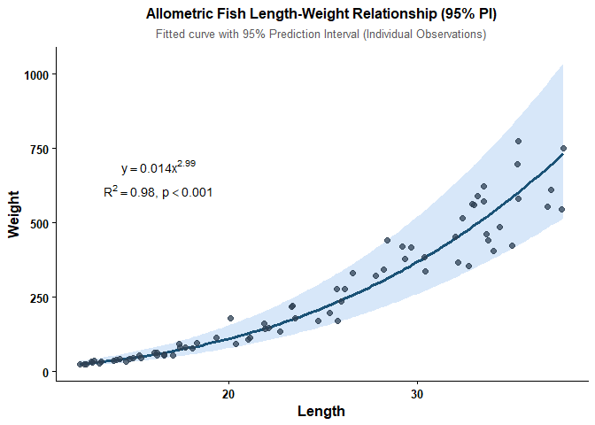

```r
res_power_reg <- regression_analysis(
  data          = fish_allometry,
  x_var         = "Length",
  y_var         = "Weight",
  fit_type      = "power",
  interval      = "prediction",
  show_equation = TRUE,
  title         = "Allometric Fish Length-Weight Relationship (95% PI)"
)

# Render allometric power plot
res_power_reg$Plot
```

#### 1.8.3.2 Style B: Exponential Growth/Decay ($y = a \cdot e^{kx}$) with 95% Confidence Interval

Models exponential trajectories (e.g., mortality catch curves, light attenuation) with confidence intervals around the expected conditional mean:

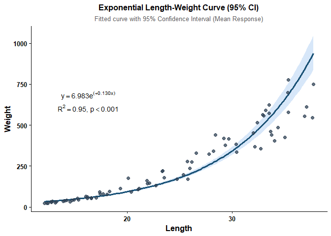

```r
res_exp_reg <- regression_analysis(
  data          = fish_allometry,
  x_var         = "Length",
  y_var         = "Weight",
  fit_type      = "exponential",
  interval      = "confidence",
  show_equation = TRUE,
  title         = "Exponential Length-Weight Curve (95% CI)"
)

# Render exponential curve
res_exp_reg$Plot
```

#### 1.8.3.3 Style C: Faceted Quadratic Polynomial ($y = \beta_0 + \beta_1 x + \beta_2 x^2$)

Fits 2nd-order polynomial curves across river systems with `facet = TRUE`, placing panel-specific equations and $R^2$ values in each sub-panel:

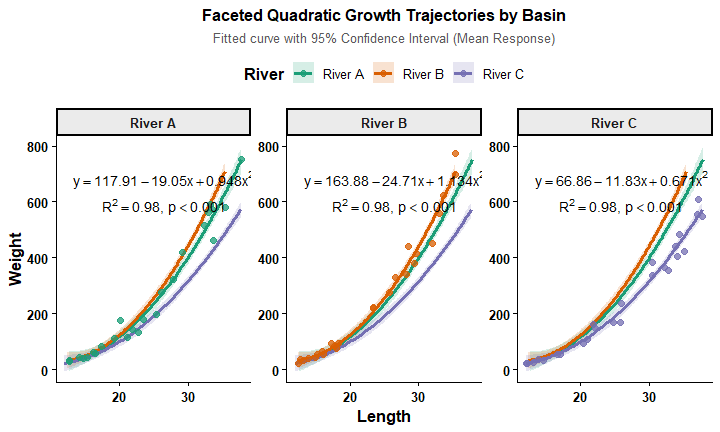

```r
res_poly_reg <- regression_analysis(
  data          = fish_allometry,
  x_var         = "Length",
  y_var         = "Weight",
  fit_type      = "polynomial",
  group_var     = "River",
  facet         = TRUE,
  interval      = "confidence",
  show_equation = TRUE,
  color_palette = "Dark2",
  title         = "Faceted Quadratic Growth Trajectories by Basin"
)

# Render faceted quadratic curves
res_poly_reg$Plot
```

#### 1.8.3.4 Style D: Faceted Cubic Polynomial ($y = \beta_0 + \beta_1 x + \beta_2 x^2 + \beta_3 x^3$)

Accommodates complex, multi-inflection trajectories (e.g., seasonal thermal tolerance limits or multi-stage cohort growth) using a 3rd-order polynomial:

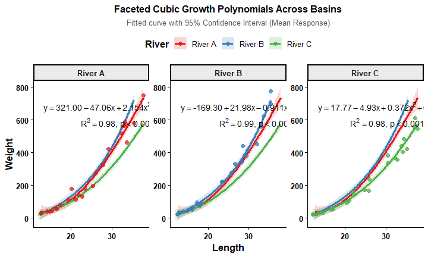

```r
res_cubic_reg <- regression_analysis(
  data          = fish_allometry,
  x_var         = "Length",
  y_var         = "Weight",
  fit_type      = "cubic",
  group_var     = "River",
  facet         = TRUE,
  interval      = "confidence",
  show_equation = TRUE,
  color_palette = "Set1",
  title         = "Faceted Cubic Growth Polynomials Across Basins"
)

# Render faceted cubic curves
res_cubic_reg$Plot
```

### 1.8.4 Model Inspection & Diagnostics

The returned list object provides access to algebraic formulas, goodness-of-fit statistics ($R^2$, $F$-test $p$-values), fitted `lm` model objects, and evaluation grids:

```r
# 1. Tidy summary of model equations, R2 values, and p-values
res_poly_reg$Equation_Table
```

```
#>     Group   Fit_Type                                Equation R_Squared P_Value
#> 1 River A polynomial y == '117.91' - '19.05'*x + '0.948'*x^2    0.9766       0
#> 2 River B polynomial y == '163.88' - '24.71'*x + '1.134'*x^2    0.9846       0
#> 3 River C polynomial  y == '66.86' - '11.83'*x + '0.671'*x^2    0.9795       0
#>                                                                                  Label
#> 1 atop(y == '117.91' - '19.05'*x + '0.948'*x^2, paste(R^2 == '0.98', ', ', p < 0.001))
#> 2 atop(y == '163.88' - '24.71'*x + '1.134'*x^2, paste(R^2 == '0.98', ', ', p < 0.001))
#> 3  atop(y == '66.86' - '11.83'*x + '0.671'*x^2, paste(R^2 == '0.98', ', ', p < 0.001))
```

```r
# 2. Inspect underlying linear model coefficients for River A
summary(res_poly_reg$Models[["River A"]])
```

```
#>
#> Call:
#> stats::lm(formula = y ~ x + x2, data = df_fit)
#>
#> Residuals:
#>     Min      1Q  Median      3Q     Max
#> -89.230 -13.681   1.514   8.028  60.074
#>
#> Coefficients:
#>             Estimate Std. Error t value Pr(>|t|)
#> (Intercept) 117.9122    83.6118   1.410   0.1725
#> x           -19.0516     7.3204  -2.603   0.0163 *
#> x2            0.9484     0.1476   6.424 1.83e-06 ***
#> ---
#> Signif. codes:  0 '***' 0.001 '**' 0.01 '*' 0.05 '.' 0.1 ' ' 1
#>
#> Residual standard error: 36.18 on 22 degrees of freedom
#> Multiple R-squared:  0.9766, Adjusted R-squared:  0.9745
#> F-statistic:   459 on 2 and 22 DF,  p-value: < 2.2e-16
```

```r
# 3. Preview calculated prediction grid with 95% confidence intervals
head(res_poly_reg$Predictions, 6)
```

```
#>          x    y_fit      y_lwr    y_upr   Group
#> 1 12.70514 28.95552 -7.0132498 64.92429 River A
#> 2 12.91573 30.06073 -4.6373997 64.75886 River A
#> 3 13.12632 31.25007 -2.2206115 64.72076 River A
#> 4 13.33692 32.52354  0.2359541 64.81112 River A
#> 5 13.54751 33.88113  2.7310749 65.03118 River A
#> 6 13.75810 35.32284  5.2634742 65.38221 River A
```

## 1.9 Generalized Linear Models (GLMs)

The `glm_analysis()` function handles non-normal aquatic survey data where standard ordinary least squares (OLS) assumptions are violated. In fisheries surveys, biodiversity assessments, and habitat modeling, empirical data frequently feature discrete integer counts with positive skew (e.g., fish catch per unit effort, abundance of invasive species) or binary presence/absence states (e.g., detection of endangered fauna or disease occurrence).

The function fits models across Poisson, Quasipoisson (for overdispersed counts), or Binomial error distributions using link functions ($g(\cdot)$). It extracts Wald parameter estimates, derives multiplicative effect metrics—Incident Rate Ratios (IRR) for count families or Odds Ratios (OR) for binary families—computes 95% Wald confidence bounds, and generates a publication-ready forest plot.

### 1.9.1 Conceptual Framework and Statistical Formulation

A Generalized Linear Model consists of three components: 1. Random Component: An exponential dispersion family distribution for the response variable $Y_i$. 2. Systematic Component: A linear predictor combination of $p$ explanatory variables:
$$\eta_i = \beta_0 + \sum_{j=1}^p \beta_j
x_{ij}$$
3. Link Function: A monotonic function $g(\cdot)$ mapping the expected mean $\mu_i = \mathbb{E}(Y_i)$ to the linear predictor:
$$\eta_i = g(\mu_i)$$

#### 1.9.1.1 Poisson and Quasipoisson Regression (Count Dynamics)

For count data (e.g., CPUE or species richness), the log link ensures strictly positive predicted yields:

$$\ln(\mu_i) = \beta_0 + \beta_1 x_{i1} +
\dots + \beta_p x_{ip}$$

Exponentiating coefficients yields the Incident Rate Ratio (IRR):

$$\text{IRR}_j =
\exp(\beta_j)$$

An $\text{IRR} > 1$ denotes a multiplicative increase in the expected count per unit increase in $x_j$, while an $\text{IRR} < 1$ represents a proportional reduction. When the variance exceeds the mean ($\text{Var}(Y) = \phi \mu$ with dispersion parameter $\phi > 1$), the `quasipoisson` family inflates parameter standard errors by $\sqrt{\phi}$ to account for overdispersion without altering point estimates.

#### 1.9.1.2 Binomial Logistic Regression (Presence / Absence)

For binary occurrence states $Y_i \in \{0, 1\}$, the logit link maps probability $p_i = P(Y_i = 1)$ to continuous space:

$$\text{logit}(p_i) =
\ln\left(\frac{p_i}{1 - p_i}\right) = \beta_0 + \beta_1 x_{i1} + \dots +
\beta_p x_{ip}$$

Exponentiating estimates yields the Odds Ratio (OR):

$$\text{OR}_j = \exp(\beta_j)$$

The 95% Wald confidence intervals for effect sizes are calculated as:

$$\text{CI}_{95\%} = \exp(\hat{\beta}_j
\pm 1.96 \times \text{SE}(\hat{\beta}_j))$$

If the confidence interval spans $1.0$, the predictor does not exert a statistically detectable multiplicative effect at $\alpha = 0.05$.

### 1.9.2 In-Vignette Data Generation

We simulate an estuarine fish survey monitoring the abundance (count per haul) of a juvenile target species across 120 sampling trawls. The response count is modeled as a function of Water Temperature (°C), Salinity (PSU), Dissolved Oxygen (mg/L), and Substrate Type (`Mud` vs. `Sand`):

```r
set.seed(707)
n_trawls <- 120

temp_c   <- runif(n_trawls, min = 18, max = 30)
sal_psu  <- runif(n_trawls, min = 5, max = 32)
do_mgl   <- runif(n_trawls, min = 3.5, max = 9.0)
substr   <- sample(c("Mud", "Sand"), size = n_trawls, replace = TRUE)

# Multiplicative linear predictor
log_mu <- -1.8 +
  0.08 * temp_c -
  0.04 * sal_psu +
  0.22 * do_mgl +
  ifelse(substr == "Sand", 0.35, 0.0)

# Simulate Poisson counts
catch_counts <- rpois(n_trawls, lambda = exp(log_mu))

trawl_survey <- data.frame(
  Abundance   = catch_counts,
  Temperature = temp_c,
  Salinity    = sal_psu,
  DO          = do_mgl,
  Substrate   = factor(substr, levels = c("Mud", "Sand"))
)

head(trawl_survey, 6)
```

```
#>   Abundance Temperature  Salinity       DO Substrate
#> 1         1    19.19934 31.872330 4.420170       Mud
#> 2         3    23.25641  7.830847 5.040356      Sand
#> 3         1    21.22099 16.444491 5.220697      Sand
#> 4         2    24.38437  5.188938 4.339394      Sand
#> 5         4    27.09255 16.775980 5.855344       Mud
#> 6         0    26.38856 12.958779 5.937050       Mud
```

### 1.9.3 Visualization Styles

The forest plot produced by `glm_analysis()` centers predictor effects relative to the reference null line at $\text{Effect Size} = 1.0$.

#### 1.9.3.1 Style A: Count Regression Forest Plot (Poisson Model)

Evaluates the Incident Rate Ratio (IRR) across environmental drivers, with horizontal error bars showing 95% confidence intervals:

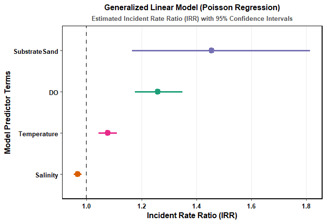

```r
res_glm_count <- glm_analysis(
  data           = trawl_survey,
  response_var   = "Abundance",
  predictor_vars = c("Temperature", "Salinity", "DO", "Substrate"),
  family_type    = "poisson",
  color_palette  = "Dark2"
)

# Render forest plot
res_glm_count$Plot
```

#### 1.9.3.2 Style B: Binary Occurrence Forest Plot (Binomial Model)

When the response variable is converted into occurrence (presence/absence), `family_type = "binomial"` generates Odds Ratios (OR):

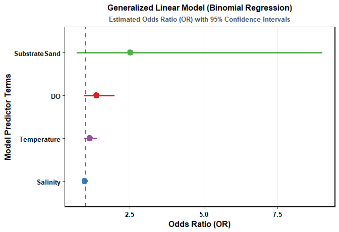

```r
# Create binary presence/absence column
trawl_survey$Presence <- ifelse(trawl_survey$Abundance > 0, 1, 0)

res_glm_binary <- glm_analysis(
  data           = trawl_survey,
  response_var   = "Presence",
  predictor_vars = c("Temperature", "Salinity", "DO", "Substrate"),
  family_type    = "binomial",
  color_palette  = "Set1"
)

res_glm_binary$Plot
```

### 1.9.4 Model Inspection and Numerical Summaries

The returned list provides the GLM model summary and a coefficient table with calculated effect sizes:

```r
# 1. Global GLM Summary (Deviance, Dispersion, Estimates, z-values, p-values)
res_glm_count$Model_Summary
```

```
#>
#> Call:
#> stats::glm(formula = formula_str, family = fam_obj, data = clean_data)
#>
#> Coefficients:
#>                Estimate Std. Error z value Pr(>|z|)
#> (Intercept)   -1.896996   0.476145  -3.984 6.77e-05 ***
#> Temperature    0.073725   0.015557   4.739 2.15e-06 ***
#> Salinity      -0.033417   0.007253  -4.607 4.08e-06 ***
#> DO             0.230767   0.035161   6.563 5.27e-11 ***
#> SubstrateSand  0.374581   0.112705   3.324 0.000889 ***
#> ---
#> Signif. codes:  0 '***' 0.001 '**' 0.01 '*' 0.05 '.' 0.1 ' ' 1
#>
#> (Dispersion parameter for poisson family taken to be 1)
#>
#>     Null deviance: 225.54  on 119  degrees of freedom
#> Residual deviance: 116.91  on 115  degrees of freedom
#> AIC: 432.46
#>
#> Number of Fisher Scoring iterations: 5
```

```r
# 2. Tidy Coefficient Table with Exponentiated Effect Sizes (IRR) and 95% CIs
res_glm_count$Coefficient_Table
```

```
#>                  Estimate   Std_Error   z_value      p_value          Term
#> Temperature    0.07372515 0.015556870  4.739074 2.146976e-06   Temperature
#> Salinity      -0.03341746 0.007253455 -4.607110 4.083048e-06      Salinity
#> DO             0.23076685 0.035161128  6.563124 5.269193e-11            DO
#> SubstrateSand  0.37458124 0.112705395  3.323543 8.888167e-04 SubstrateSand
#>               Effect_Size  Lower_CI  Upper_CI
#> Temperature     1.0765109 1.0441819 1.1098408
#> Salinity        0.9671347 0.9534825 0.9809825
#> DO              1.2595655 1.1756851 1.3494305
#> SubstrateSand   1.4543823 1.1661161 1.8139083
```

## 1.10 Non-metric Multidimensional Scaling (NMDS)

The `nmds_analysis()` function performs unconstrained multivariate ordination for community composition datasets (e.g., phytoplankton, zooplankton, macroinvertebrates, and fish assemblages). Unlike eigenvalue-based ordination techniques (e.g., PCA), NMDS avoids assuming linear relationships between species abundances and underlying environmental gradients. Instead, it relies on rank-order dissimilarities, making it resilient to zero-inflated ecological count matrices.

The function supports input ingestion (data frames, matrices, lists), implements standard ecological transformations (e.g., Hellinger, Wisconsin double standardization), runs iterative ordination using `vegan::metaMDS`, monitors convergence stress, overlays 95% normal confidence ellipses, and projects significant environmental vectors using `vegan::envfit`.

### 1.10.1 Conceptual Framework and Mathematical Formulation

Let $\mathbf{Y}_{n \times p}$ denote a community matrix of $n$ sampling sites and $p$ taxa. Pairwise ecological dissimilarity between site $j$ and site $k$ is calculated using an appropriate index (typically Bray-Curtis dissimilarity for abundance data):

$$d_{jk} = \frac{\sum_{i=1}^p |y_{ij} -
y_{ik}|}{\sum_{i=1}^p (y_{ij} + y_{ik})}$$

NMDS seeks a low-dimensional configuration ($k = 2$ or $3$ dimensions) of site coordinates $\mathbf{X}_{n \times k}$ such that the Euclidean distances between points in ordination space ($\hat{d}_{jk} = \Vert{}\mathbf{x}_j - \mathbf{x}_k\Vert{}$) preserve the monotonic rank order of the original dissimilarities ($d_{jk}$):

$$d_{jk} \approx
f(\hat{d}_{jk})$$

where $f$ is a monotonic step or regression function fitted using isotonic regression.

#### 1.10.1.1 Stress Evaluation and Quality Criteria

The goodness-of-fit of the configuration is measured by Kruskal’s Stress ($S$):

$$S = \sqrt{\frac{\sum_{j < k} (d_{jk}
- \hat{d}_{jk})^2}{\sum_{j < k} d_{jk}^2}}$$

Stress measures the rank-order discrepancy between original ecological dissimilarities and low-dimensional mapped distances: - $S < 0.05$: Excellent representation with minimal distortion. - $0.05 \le S < 0.10$: Good ordination with reliable configuration. - $0.10 \le S \le 0.20$: Usable ordination; 2D configuration provides an adequate representation, but higher-order details should be interpreted with care. - $S > 0.20$: High stress; results should be interpreted cautiously, and increasing ordination dimensionality ($k = 3$) may be warranted.

#### 1.10.1.2 Pre-Ordination Hellinger Transformation

To alleviate the “horseshoe” or “arch” effect common in raw Euclidean distance models, `transform = "hellinger"` applies the Hellinger metric:

$$y'_{ij} =
\sqrt{\frac{y_{ij}}{\sum_{m=1}^p y_{mj}}}$$

This downweights dominant taxa and eliminates the zero-inflation paradox without dropping absent species.

### 1.10.2 In-Vignette Data Generation

We simulate a river basin macroinvertebrate community survey across 45 sampling stations distributed among three Habitat types (`Riffle`, `Run`, `Pool`). Seven diagnostic taxa counts are generated, along with three continuous water quality parameters (Flow Velocity, Dissolved Oxygen, and Water Temperature):

```r
set.seed(808)
n_sites <- 15
habitats <- c("Riffle", "Run", "Pool")

# Macroinvertebrate community matrix (7 diagnostic taxa)
comm_list <- lapply(habitats, function(hab) {
  # Baseline taxon abundance profiles
  means <- switch(hab,
    "Riffle" = c(Ephem = 28, Plecop = 22, Trichop = 18, Chirono = 4,  Oligoch = 1,  Odonat = 2,  Gastrop = 1),
    "Run"    = c(Ephem = 12, Plecop = 8,  Trichop = 14, Chirono = 16, Oligoch = 6,  Odonat = 5,  Gastrop = 3),
    "Pool"   = c(Ephem = 2,  Plecop = 0,  Trichop = 4,  Chirono = 32, Oligoch = 24, Odonat = 12, Gastrop = 18)
  )

  # Simulate Poisson counts
  mat <- do.call(cbind, lapply(means, function(m) rpois(n_sites, lambda = m)))
  df <- as.data.frame(mat)
  df$Habitat <- hab
  df
})

macro_data <- do.call(rbind, comm_list)
# Place metadata as first column
macro_data <- macro_data[, c("Habitat", setdiff(names(macro_data), "Habitat"))]

# Corresponding environmental matrix
env_data <- data.frame(
  Velocity_ms = c(rnorm(n_sites, 0.85, 0.1), rnorm(n_sites, 0.45, 0.08), rnorm(n_sites, 0.12, 0.04)),
  DO_mgl      = c(rnorm(n_sites, 9.2, 0.4),  rnorm(n_sites, 7.8, 0.5),   rnorm(n_sites, 5.4, 0.6)),
  Temp_C      = c(rnorm(n_sites, 19.5, 0.8), rnorm(n_sites, 22.0, 0.7),  rnorm(n_sites, 25.8, 1.1))
)

head(macro_data[, 1:6], 6)
```

```
#>   Habitat Ephem Plecop Trichop Chirono Oligoch
#> 1  Riffle    35     15      23       3       2
#> 2  Riffle    26     21      19       3       2
#> 3  Riffle    39     22      19       2       0
#> 4  Riffle    19     18      24       4       1
#> 5  Riffle    25     31      19       0       0
#> 6  Riffle    26     29      25       1       0
```

### 1.10.3 Visualization Styles

`nmds_analysis()` displays sample site scores color-coded by habitat with 95% confidence ellipses, and can overlay significant environmental gradient vectors.

#### 1.10.3.1 Style A: Community Ordination with 95% Confidence Ellipses

Computes Hellinger-transformed Bray-Curtis NMDS ordination and projects cluster confidence regions:

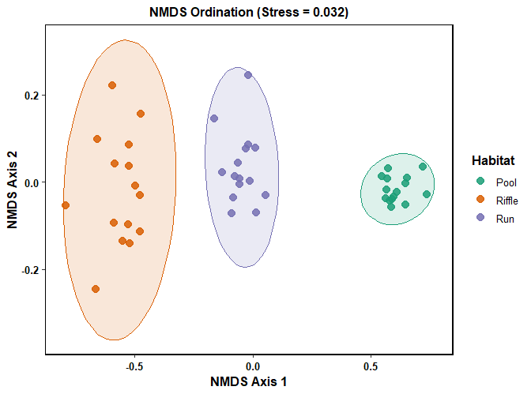

```r
res_nmds <- nmds_analysis(
  data        = macro_data,
  group_col   = "Habitat",
  transform   = "hellinger",
  dist_method = "bray",
  palette     = "Dark2"
)

# Render ordination plot
res_nmds$Plot
```

#### 1.10.3.2 Style B: Community Ordination with Environmental Vector Fitting (`envfit`)

Supplying `env_data` automatically runs `vegan::envfit` (999 permutations) and projects significant ($p \le 0.05$) environmental directional arrows into the ordination space:

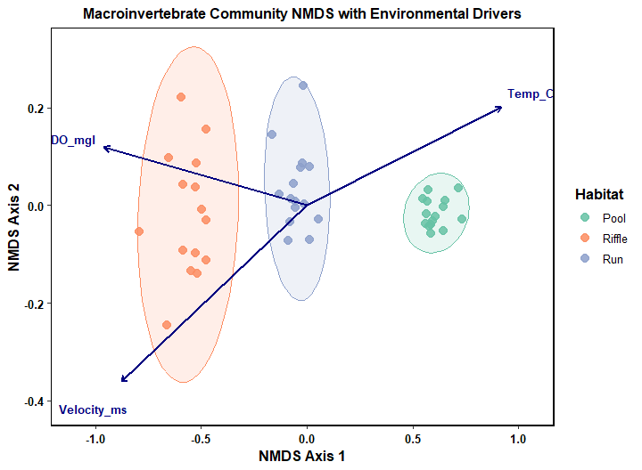

```r
res_nmds_env <- nmds_analysis(
  data        = macro_data,
  group_col   = "Habitat",
  env_data    = env_data,
  transform   = "hellinger",
  dist_method = "bray",
  palette     = "Set2",
  title       = "Macroinvertebrate Community NMDS with Environmental Drivers"
)

res_nmds_env$Plot
```

### 1.10.4 Model Inspection and Numerical Summaries

The returned list provides the stress value, tidy site coordinate scores, underlying `metaMDS` object, and permutation vector fits:

```r
# 1. Final Ordination Stress
res_nmds$Stress
```

```
#> [1] 0.03217201
```

```r
# 2. Tidy NMDS Axis Coordinates
head(res_nmds$Plot_Data, 6)
```

```
#>        NMDS1        NMDS2 Habitat
#> 1 -0.5252891  0.037631731  Riffle
#> 2 -0.4970030 -0.007769052  Riffle
#> 3 -0.5858803 -0.092789932  Riffle
#> 4 -0.4764525 -0.030577205  Riffle
#> 5 -0.6635751 -0.245218978  Riffle
#> 6 -0.7915610 -0.054026622  Riffle
```

```r
# 3. Environmental Vector Fits (r2, p-values)
res_nmds_env$Envfit_Results
```

```
#>
#> ***VECTORS
#>
#>                NMDS1    NMDS2     r2 Pr(>r)
#> Velocity_ms -0.92515 -0.37960 0.9032  0.001 ***
#> DO_mgl      -0.99241  0.12297 0.9357  0.001 ***
#> Temp_C       0.97695  0.21348 0.8872  0.001 ***
#> ---
#> Signif. codes:  0 '***' 0.001 '**' 0.01 '*' 0.05 '.' 0.1 ' ' 1
#> Permutation: free
#> Number of permutations: 999
```

## 1.11 Permutational Multivariate Analysis of Variance (PERMANOVA)

The `permanova_analysis()` function performs non-parametric multivariate hypothesis testing on ecological distance matrices using `vegan::adonis2`. While ordination techniques such as NMDS graphically portray patterns of community resemblance, PERMANOVA tests whether spatial, seasonal, or experimental groups occupy statistically distinct regions in multivariate ecological space.

Because community data are non-normal, zero-inflated, and contain complex species co-dependencies, standard parametric MANOVA assumptions (multivariate normality and homogeneous covariance matrices) are regularly violated. PERMANOVA resolves this by partitioning dissimilarity matrices and calculating significance via permutation testing.

### 1.11.1 Conceptual Framework and Statistical Formulation

Let $\mathbf{D} = [d_{ij}]$ represent an $N \times N$ symmetric ecological distance matrix (e.g., Bray-Curtis or Euclidean distances) among $N$ samples across $g$ distinct groups. The total sum of squared dissimilarities ($\text{SS}_{\text{Total}}$) is partitioned into within-group ($\text{SS}_W$) and between-group ($\text{SS}_A$) components:

$$\text{SS}_{\text{Total}} = \frac{1}{N}
\sum_{i=1}^{N-1} \sum_{j=i+1}^N d_{ij}^2$$

$$\text{SS}_W = \sum_{k=1}^g \frac{1}{n_k}
\sum_{i=1}^{n_k-1} \sum_{j=i+1}^{n_k} d_{ij(k)}^2$$

$$\text{SS}_A = \text{SS}_{\text{Total}} -
\text{SS}_W$$

where $n_k$ is the sample size in group $k$.

#### 1.11.1.1 The Pseudo-$F$ Test Statistic

The non-parametric pseudo-$F$ statistic compares the between-group variance to within-group variance:

$$F = \frac{\text{SS}_A / (g -
1)}{\text{SS}_W / (N - g)}$$

Because the null distribution of pseudo-$F$ does not follow an ordinary parametric $F$-distribution under arbitrary distance metrics, significance ($p$-value) is determined through Monte Carlo permutation of sample labels:

$$p = \frac{\sum_{m=1}^M
\mathbb{I}(F^{\pi}_m \ge F_{\text{obs}}) + 1}{M + 1}$$

where $M$ is the number of permutations (typically 999), $F_{\text{obs}}$ is the pseudo-$F$ calculated on the intact dataset, and $F^{\pi}_m$ is the pseudo-$F$ obtained from the $m$-th randomly permuted configuration.

### 1.11.2 In-Vignette Data Generation

We simulate a marine benthic community monitoring study assessing macrobenthic invertebrate abundances across three seabed sediment classes (`Coarse Gravel`, `Fine Sand`, and `Silty Mud`):

```r
set.seed(909)
n_reps <- 12

substrates <- c("Coarse Gravel", "Fine Sand", "Silty Mud")

benthic_survey <- do.call(rbind, lapply(substrates, function(sub) {
  # Diagnostic species abundance baselines
  means <- switch(sub,
    "Coarse Gravel" = c(Polychaeta = 14, Bivalvia = 6,  Amphipoda = 28, Decapoda = 12, Echinodermata = 16),
    "Fine Sand"     = c(Polychaeta = 22, Bivalvia = 18, Amphipoda = 15, Decapoda = 8,  Echinodermata = 4),
    "Silty Mud"     = c(Polychaeta = 35, Bivalvia = 26, Amphipoda = 4,  Decapoda = 2,  Echinodermata = 1)
  )

  mat <- do.call(cbind, lapply(means, function(m) rpois(n_reps, lambda = m)))
  df <- as.data.frame(mat)
  df$Substrate <- sub
  df
}))

# Organize Substrate as grouping metadata column
benthic_survey <- benthic_survey[, c("Substrate", setdiff(names(benthic_survey), "Substrate"))]

head(benthic_survey, 6)
```

```
#>       Substrate Polychaeta Bivalvia Amphipoda Decapoda Echinodermata
#> 1 Coarse Gravel         17       10        23       11            15
#> 2 Coarse Gravel         14       15        33        9            21
#> 3 Coarse Gravel         14       12        40       15            23
#> 4 Coarse Gravel         11        6        31       13            14
#> 5 Coarse Gravel         19        5        26       13            15
#> 6 Coarse Gravel          9        7        23       10            14
```

### 1.11.3 Statistical Execution and Permutation Testing

We test for differences in community structure across substrate types using the Bray-Curtis distance metric with Hellinger pre-transformation:

```r
res_permanova <- permanova_analysis(
  data         = benthic_survey,
  group_col    = "Substrate",
  dist_method  = "bray",
  transform    = "hellinger",
  permutations = 999,
  seed         = 42
)
```

### 1.11.4 Model Inspection and Numerical Summaries

The returned list provides the ANOVA-style summary table detailing degrees of freedom, sum-of-squares, $R^2$ (variation explained by the grouping factor), pseudo-$F$ values, and permutation-based $p$-values:

```r
# 1. PERMANOVA Table (adonis2 results)
res_permanova$PERMANOVA_Table
```

```
#> Permutation test for adonis under reduced model
#> Permutation: free
#> Number of permutations: 999
#>
#> vegan::adonis2(formula = formula_obj, data = design_df, permutations = permutations, method = dist_method)
#>          Df SumOfSqs      R2      F Pr(>F)
#> Model     2  0.86869 0.89866 146.32  0.001 ***
#> Residual 33  0.09796 0.10134
#> Total    35  0.96665 1.00000
#> ---
#> Signif. codes:  0 '***' 0.001 '**' 0.01 '*' 0.05 '.' 0.1 ' ' 1
```

```r
# 2. Distance Metric Applied
res_permanova$Distance_Method
```

```
#> [1] "bray"
```

```r
# 3. Cleaned and Transformed Data Preview
head(res_permanova$Cleaned_Data, 4)
```

```
#>           Group Polychaeta  Bivalvia Amphipoda  Decapoda Echinodermata
#> 1 Coarse Gravel  0.4729527 0.3627381 0.5501196 0.3804430     0.4442617
#> 2 Coarse Gravel  0.3900947 0.4037864 0.5989121 0.3127716     0.4777665
#> 3 Coarse Gravel  0.3668997 0.3396831 0.6201737 0.3797773     0.4702700
#> 4 Coarse Gravel  0.3829708 0.2828427 0.6429101 0.4163332     0.4320494
```

## 1.12 Similarity Percentages (SIMPER) Analysis

The `simper_analysis()` function identifies which individual taxa or species drive community-level differences between ecological groups. While NMDS visualizes spatial or experimental separation and PERMANOVA evaluates whether those differences are statistically significant, SIMPER (Similarity Percentages) decomposes the overall Bray-Curtis dissimilarity into percentage contributions attributable to each individual taxon.

In fisheries ecology, benthic surveys, and aquatic biomonitoring, SIMPER serves as an indicator species detection tool—revealing which particular taxa characterize undisturbed reference sites versus human-impacted habitats, or which species drive seasonal community turnover.

### 1.12.1 Conceptual Framework and Mathematical Formulation

Consider two groups of samples, Group $1$ and Group $2$. The Bray-Curtis dissimilarity between sample $j$ in Group $1$ and sample $k$ in Group $2$ is given by:

$$d_{jk} = \frac{\sum_{i=1}^p |y_{ij} -
y_{ik}|}{\sum_{i=1}^p (y_{ij} + y_{ik})}$$

SIMPER decomposes this total dissimilarity into the specific contribution of the $i$-th taxon:

$$\delta_{jk}^{(i)} = \frac{|y_{ij} -
y_{ik}|}{\sum_{m=1}^p (y_{mj} + y_{mk})}$$

#### 1.12.1.1 Average Contribution and Diagnostic Ratios

The average contribution of species $i$ ($\bar{\delta}_i$) across all $n_1 \times n_2$ pairwise comparisons between Group $1$ and Group $2$ is:

$$\bar{\delta}_i = \frac{1}{n_1 n_2}
\sum_{j=1}^{n_1} \sum_{k=1}^{n_2} \delta_{jk}^{(i)}$$

Taxa are ranked in descending order of $\bar{\delta}_i$. The cumulative percentage contribution of the top $m$ species is:

$$\text{Cumulative Contribution (\%)} =
\frac{\sum_{i=1}^m \bar{\delta}_i}{\sum_{i=1}^p \bar{\delta}_i} \times
100$$

A high average contribution combined with a consistent ratio of contribution to standard deviation indicates that a species is a reliable discriminator between the two environmental or biological groups.

### 1.12.2 In-Vignette Data Generation

We simulate a lake fish assemblage survey monitoring abundances across three habitat zones (`Littoral`, `Pelagic`, and `Profundal`). Six representative fish taxa are surveyed across 36 sampling stations:

```r
set.seed(1010)
n_stations <- 12
zones <- c("Littoral", "Pelagic", "Profundal")

lake_survey <- do.call(rbind, lapply(zones, function(zn) {
  # Distinct abundance profiles across lake zones
  means <- switch(zn,
    "Littoral"  = c(Perch = 32, Pike = 8,  Roach = 45, Bream = 22, Bleak = 12, Zander = 2),
    "Pelagic"   = c(Perch = 10, Pike = 1,  Roach = 18, Bream = 6,  Bleak = 55, Zander = 14),
    "Profundal" = c(Perch = 2,  Pike = 0,  Roach = 4,  Bream = 1,  Bleak = 2,  Zander = 28)
  )

  mat <- do.call(cbind, lapply(means, function(m) rpois(n_stations, lambda = m)))
  df <- as.data.frame(mat)
  df$Zone <- zn
  df
}))

# Organize Zone as grouping metadata column
lake_survey <- lake_survey[, c("Zone", setdiff(names(lake_survey), "Zone"))]

head(lake_survey, 6)
```

```
#>       Zone Perch Pike Roach Bream Bleak Zander
#> 1 Littoral    32   10    45    34     8      0
#> 2 Littoral    26    8    49    17    12      3
#> 3 Littoral    37    6    38    25    11      3
#> 4 Littoral    43    7    47    24    15      0
#> 5 Littoral    36    6    30    20    17      1
#> 6 Littoral    37   11    42    21    11      1
```

### 1.12.3 Visualization Styles

The `simper_analysis()` function extracts the top $N$ taxa contributing to dissimilarity for each pairwise comparison and displays them using faceted horizontal bar charts.

#### 1.12.3.1 Style A: Faceted Top Contributing Taxa (Default)

Decomposes all pairwise group comparisons (`Littoral_Pelagic`, `Littoral_Profundal`, `Pelagic_Profundal`) and displays the top 5 discriminating species per comparison:

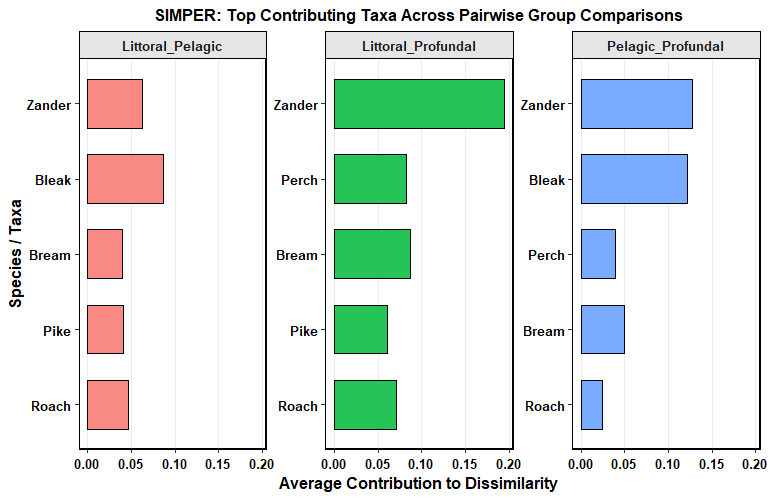

```r
res_simper <- simper_analysis(
  data         = lake_survey,
  group_col    = "Zone",
  top_n        = 5,
  transform    = "hellinger",
  permutations = 999,
  seed         = 42
)

# Render faceted contribution plot
res_simper$Plot
```

### 1.12.4 Model Inspection and Numerical Summaries

The returned list contains the raw `vegan::simper` object, along with a tidy data frame listing each species’ average contribution, cumulative percentage, and permutation $p$-value:

```r
# 1. Tidy summary table of top discriminating taxa
head(res_simper$Summary_Table, 10)
```

```
#>            Comparison Species Contribution Cumulative p_value
#> 1    Littoral_Pelagic   Bleak   0.08738423  0.2736940   0.001
#> 2    Littoral_Pelagic  Zander   0.06289710  0.4706925   1.000
#> 3    Littoral_Pelagic   Roach   0.04713252  0.6183151   0.010
#> 4    Littoral_Pelagic    Pike   0.04134981  0.7478258   0.001
#> 5    Littoral_Pelagic   Bream   0.04036191  0.8742423   0.976
#> 6  Littoral_Profundal  Zander   0.19514771  0.3706790   0.001
#> 7  Littoral_Profundal   Bream   0.08759999  0.5370734   0.001
#> 8  Littoral_Profundal   Perch   0.08316557  0.6950446   0.001
#> 9  Littoral_Profundal   Roach   0.07154487  0.8309426   0.001
#> 10 Littoral_Profundal    Pike   0.06068598  0.9462144   0.001
```

```r
# 2. Inspect raw vegan SIMPER summary for a specific comparison
summary(res_simper$SIMPER_Object)$Littoral_Pelagic[1:5, ]
```

```
#>           average         sd    ratio       ava        avb    cumsum     p
#> Bleak  0.08738423 0.01342109 6.510964 0.3272274 0.70611825 0.2736940 0.001
#> Zander 0.06289710 0.01653698 3.803422 0.1018942 0.37505851 0.4706925 1.000
#> Roach  0.04713252 0.01538010 3.064513 0.6116993 0.40663320 0.6183151 0.010
#> Pike   0.04134981 0.01655756 2.497337 0.2377041 0.05898552 0.7478258 0.001
#> Bream  0.04036191 0.01918986 2.103294 0.4205971 0.24640228 0.8742423 0.976
```

## 1.13 Principal Component Analysis (PCA) Community Biplot

The `pca_community_biplot()` function performs unconstrained linear ordination using Principal Component Analysis (`vegan::rda()`) to project aquatic communities into a reduced orthogonal subspace. While non-metric multidimensional scaling (NMDS) is non-parametric and rank-based, PCA constructs synthetic axes that maximize total explained variance.

A key advantage of PCA for ecological communities is the simultaneous display of both sampling sites (points) and taxa (loadings) as directional vectors—forming a classical biplot. In this representation, the cosine of the angle between two species vectors approximates their linear correlation, while the projection of site points onto a species arrow indicates the relative abundance of that taxon at those sampling stations.

### 1.13.1 Conceptual Framework and Mathematical Formulation

Let $\mathbf{Y}_{n \times p}$ denote an abundance or biomass matrix of $n$ sampling sites and $p$ aquatic species. PCA decomposes the centered (and optionally standardized) variance-covariance matrix $\mathbf{S} = \frac{1}{n-1} \mathbf{Y}^T \mathbf{Y}$ via singular value decomposition (SVD) or spectral decomposition:

$$\mathbf{S} = \mathbf{V}
\boldsymbol{\Lambda} \mathbf{V}^T$$

where: - $\boldsymbol{\Lambda} = \text{diag}(\lambda_1, \lambda_2, \dots, \lambda_p)$ is the diagonal matrix of eigenvalues sorted in descending order ($\lambda_1 \ge \lambda_2 \ge \dots \ge \lambda_p \ge 0$), - $\mathbf{V} = [\mathbf{v}_1, \mathbf{v}_2, \dots, \mathbf{v}_p]$ is the matrix of orthonormal eigenvectors containing the species loadings.

The percentage of total community variance explained by the $k$-th principal component ($\text{PC}_k$) is:

$$\text{Variance Explained (\%)} =
\frac{\lambda_k}{\sum_{m=1}^p \lambda_m} \times 100$$

Site coordinates in the reduced 2D ordination space are computed as:

$$\mathbf{F} = \mathbf{Y}
\mathbf{V}_2$$

where $\mathbf{V}_2$ denotes the first two eigenvector columns corresponding to $\lambda_1$ and $\lambda_2$.

#### 1.13.1.1 Transformation-Based PCA (tb-PCA)

Raw Euclidean distance applied to unstandardized species counts can suffer from the “horseshoe” or “arch” artifact because double zeros (joint absences) are treated as evidence of ecological similarity. To address this, `transform = "hellinger"` applies Legendre & Gallagher’s Hellinger transformation prior to ordination:

$$y'_{ij} =
\sqrt{\frac{y_{ij}}{\sum_{m=1}^p y_{mj}}}$$

This tb-PCA preserves Hellinger distances among samples, making PCA well suited for compositional abundance data.

### 1.13.2 In-Vignette Data Generation

We simulate an estuarine zooplankton community survey evaluating counts of eight diagnostic taxa across three distinct salinity regimes (`Oligohaline`, `Mesohaline`, and `Polyhaline`):

```r
set.seed(1111)
n_samples <- 14
salinity_regimes <- c("Oligohaline", "Mesohaline", "Polyhaline")

zooplankton_data <- do.call(rbind, lapply(salinity_regimes, function(reg) {
  # Diagnostic zooplankton abundance profiles across salinity regimes
  means <- switch(reg,
    "Oligohaline" = c(Rotifer_A = 48, Rotifer_B = 35, Cladocera_A = 26, Cladocera_B = 18, Cyclopoid = 12, Calanoid = 4,  Mysid = 1,  Cirripede = 0),
    "Mesohaline"  = c(Rotifer_A = 12, Rotifer_B = 8,  Cladocera_A = 14, Cladocera_B = 22, Cyclopoid = 32, Calanoid = 28, Mysid = 9,  Cirripede = 5),
    "Polyhaline"  = c(Rotifer_A = 2,  Rotifer_B = 0,  Cladocera_A = 3,  Cladocera_B = 4,  Cyclopoid = 15, Calanoid = 42, Mysid = 24, Cirripede = 38)
  )

  mat <- do.call(cbind, lapply(means, function(m) rpois(n_samples, lambda = m)))
  df <- as.data.frame(mat)
  df$Salinity_Zone <- reg
  df
}))

# Place metadata as first column
zooplankton_data <- zooplankton_data[, c("Salinity_Zone", setdiff(names(zooplankton_data), "Salinity_Zone"))]

head(zooplankton_data[, 1:6], 6)
```

```
#>   Salinity_Zone Rotifer_A Rotifer_B Cladocera_A Cladocera_B Cyclopoid
#> 1   Oligohaline        47        34          26          15         9
#> 2   Oligohaline        57        29          28          12        12
#> 3   Oligohaline        52        48          19          15        16
#> 4   Oligohaline        56        30          26          15        10
#> 5   Oligohaline        48        42          29          16        13
#> 6   Oligohaline        27        36          27          23        14
```

### 1.13.3 Visualization Styles

`pca_community_biplot()` plots site coordinates, adds 95% normal confidence ellipses around environmental groups, and displays directional species loading vectors.

#### 1.13.3.1 Style A: Hellinger-Transformed PCA Community Biplot (Default)

Applies Hellinger transformation to avoid double-zero distortions while visualizing all species loading vectors alongside salinity cluster groupings:

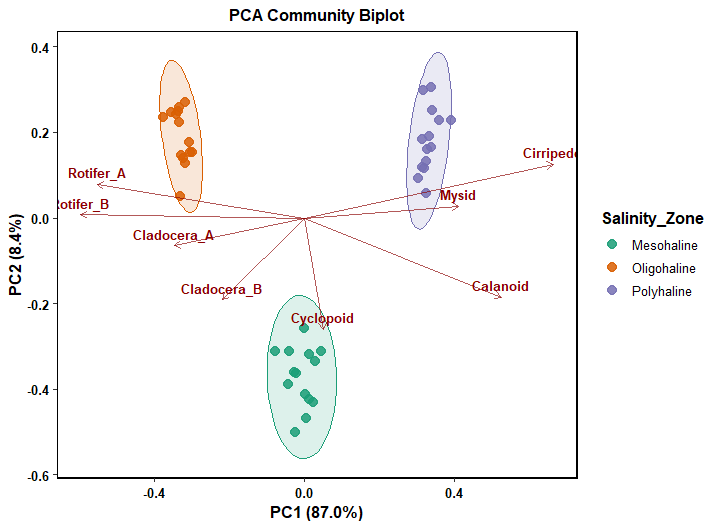

```r
res_pca_biplot <- pca_community_biplot(
  data             = zooplankton_data,
  group_col        = "Salinity_Zone",
  transform        = "hellinger",
  scale            = FALSE,
  color_palette    = "Dark2",
  arrow_multiplier = 0.8
)

# Render community biplot
res_pca_biplot$Plot
```

#### 1.13.3.2 Style B: Biplot with Top-Contributing Species Filtered

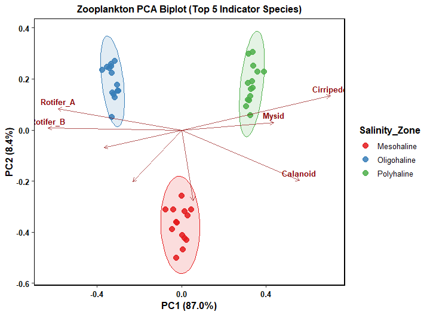

```r
res_pca_top5 <- pca_community_biplot(
  data             = zooplankton_data,
  group_col        = "Salinity_Zone",
  transform        = "hellinger",
  top_n_species    = 5,
  color_palette    = "Set1",
  arrow_multiplier = 0.85,
  title            = "Zooplankton PCA Biplot (Top 5 Indicator Species)"
)

res_pca_top5$Plot
```

### 1.13.4 Model Inspection and Numerical Summaries

The returned list provides the underlying `vegan::rda` model, coordinates of site scores with group labels, and species loading vector magnitudes:

```r
# 1. Inspect species vector coordinates and loading lengths
head(res_pca_biplot$Species_Scores, 6)
```

```
#>                     PC1          PC2     Species Vector_Length
#> Rotifer_A   -0.55197481  0.078411347   Rotifer_A     0.5575164
#> Rotifer_B   -0.59577347  0.007136423   Rotifer_B     0.5958162
#> Cladocera_A -0.34527594 -0.064900831 Cladocera_A     0.3513226
#> Cladocera_B -0.21734139 -0.190612221 Cladocera_B     0.2890853
#> Cyclopoid    0.05250865 -0.259792134   Cyclopoid     0.2650455
#> Calanoid     0.52674486 -0.185815423    Calanoid     0.5585584
```

```r
# 2. Site ordination coordinates (PC1 and PC2 scores)
head(res_pca_biplot$Plot_Data, 6)
```

```
#>             PC1        PC2 Salinity_Zone
#> sit1 -0.3314896 0.22274565   Oligohaline
#> sit2 -0.3336086 0.25922694   Oligohaline
#> sit3 -0.3051546 0.17602933   Oligohaline
#> sit4 -0.3545453 0.24684867   Oligohaline
#> sit5 -0.3411016 0.24157699   Oligohaline
#> sit6 -0.3295956 0.05113759   Oligohaline
```

```r
# 3. Eigenvalues and total variance summary
summary(res_pca_biplot$PCA_Object)$cont$importance[, 1:2]
```

```
#>                             PC1        PC2
#> Eigenvalue            0.2023484 0.01946336
#> Proportion Explained  0.8698830 0.08367175
#> Cumulative Proportion 0.8698830 0.95355472
```

## 1.14 PCA Correlation Circle for Environmental Parameters

The `pca_correlation_circle()` function visualizes the relationship among multidimensional environmental, limnological, and hydrochemical variables using a PCA variables factor map (correlation circle). When analyzing water quality matrices (e.g., pH, dissolved oxygen, nutrients, heavy metal concentrations, conductivity), variables are measured on different physical scales and often exhibit collinearities.

The function standardizes environmental variables to unit variance ($\mu = 0, \sigma = 1$), extracts variable correlations with the leading principal components, evaluates the quality of representation using the squared cosine ($\cos^2$) metric, and projects the variables within a unit correlation circle.

### 1.14.1 Conceptual Framework and Mathematical Formulation

Let $\mathbf{X}_{n \times p}$ denote an environmental dataset containing $n$ water sampling stations and $p$ physico-chemical parameters. Standardizing columns to unit variance yields:

$$z_{ij} = \frac{x_{ij} -
\bar{x}_j}{s_j}$$

PCA on the standardized matrix decomposes the Pearson correlation matrix $\mathbf{R} = \frac{1}{n-1} \mathbf{Z}^T \mathbf{Z}$:

$$\mathbf{R} = \mathbf{V}
\boldsymbol{\Lambda} \mathbf{V}^T$$

The coordinate of variable $j$ along principal component $k$ represents the Pearson correlation coefficient between that environmental variable and component axis $k$:

$$r(x_j, \text{PC}_k) = v_{jk}
\sqrt{\lambda_k}$$

where $v_{jk}$ is the eigenvector loading and $\lambda_k$ is the eigenvalue of the $k$-th principal component.

#### 1.14.1.1 The Unit Circle and $\cos^2$ Metric

Because the variables are normalized, the maximum theoretical length of any vector in the full $p$-dimensional space is $1.0$. When projected onto the 2D plane defined by $\text{PC}_1$ and $\text{PC}_2$, the squared distance from the origin represents the squared cosine ($\cos^2$):

$$\cos^2_j = r(x_j, \text{PC}_1)^2 +
r(x_j, \text{PC}_2)^2$$

Interpretation criteria: - $\cos^2 \to 1.0$ (Vector touches the unit circle): The variable is well represented in the selected 2D ordination plane; its position and angles accurately reflect relationships with other variables. - $\cos^2 \to 0$ (Vector remains near the center): The variable is poorly represented in this 2D projection; inferences about its dynamics should be confirmed using higher-order principal components. - Angle Between Vectors: - $\theta \approx 0^\circ$ ($\cos \theta \to +1$): Strong positive correlation. - $\theta \approx 90^\circ$ ($\cos \theta \to 0$): Orthogonal (uncorrelated) variables. - $\theta \approx 180^\circ$ ($\cos \theta \to -1$): Strong inverse correlation.

### 1.14.2 In-Vignette Data Generation

We simulate a limnological survey measuring eight physico-chemical water quality parameters across 40 sampling stations along a river-to-reservoir transition:

```r
set.seed(1212)
n_stations <- 40

# Simulate correlated water quality gradients
temperature <- rnorm(n_stations, mean = 24.5, sd = 3.0)
do_mgl      <- 14.5 - (0.35 * temperature) + rnorm(n_stations, 0, 0.5)
ph_val      <- 7.2 + (0.04 * temperature) + rnorm(n_stations, 0, 0.3)
turbidity   <- runif(n_stations, 5, 45)
secchi_cm   <- 120 - (2.1 * turbidity) + rnorm(n_stations, 0, 4)
bod_mgl     <- 1.2 + (0.08 * turbidity) + rnorm(n_stations, 0, 0.4)
nitrate_mgl <- rnorm(n_stations, mean = 2.4, sd = 0.6)
phosphate   <- 0.15 + (0.05 * nitrate_mgl) + rnorm(n_stations, 0, 0.03)

water_quality <- data.frame(
  StationID   = paste0("ST_", sprintf("%02d", 1:n_stations)),
  Temperature = temperature,
  DO          = do_mgl,
  pH          = ph_val,
  Turbidity   = turbidity,
  Secchi      = secchi_cm,
  BOD         = bod_mgl,
  Nitrate     = nitrate_mgl,
  Phosphate   = phosphate
)

head(water_quality, 6)
```

```
#>   StationID Temperature       DO       pH Turbidity    Secchi      BOD  Nitrate
#> 1     ST_01    22.61274 6.874055 7.905515  10.44149 104.99044 2.405120 2.033309
#> 2     ST_02    30.01227 3.943311 7.917997  16.77372  88.49811 2.137321 2.090744
#> 3     ST_03    25.53104 5.307665 8.238213  11.67667  97.99624 2.446044 2.602819
#> 4     ST_04    20.41971 6.597412 8.412772  18.24393  85.96159 2.811601 2.239365
#> 5     ST_05    26.10744 5.302458 7.879704  32.13295  45.15147 3.525980 2.781280
#> 6     ST_06    24.61160 5.835160 8.248662  19.75954  74.96844 3.245458 1.809519
#>   Phosphate
#> 1 0.2599896
#> 2 0.2041083
#> 3 0.2793542
#> 4 0.2462373
#> 5 0.2738273
#> 6 0.2417423
```

### 1.14.3 Visualization Styles

The `pca_correlation_circle()` function generates a unit circle with variables colored according to their representation quality ($\cos^2$).

#### 1.14.3.1 Style A: Standard Correlation Circle with $\cos^2$ Gradient (PC1 vs PC2)

Excludes the identifier column (`exclude_cols = "StationID"`), projects variables onto $\text{PC}_1$ and $\text{PC}_2$, and applies a color scale based on representation quality:

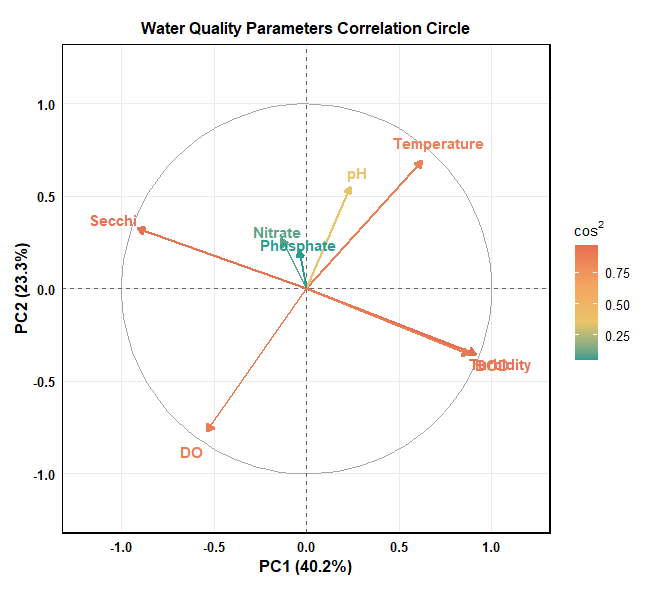

```r
res_pca_circle <- pca_correlation_circle(
  data         = water_quality,
  exclude_cols = "StationID",
  dim1         = 1,
  dim2         = 2,
  palette      = c("#2A9D8F", "#E9C46A", "#F4A261", "#E76F51"),
  title        = "Water Quality Parameters Correlation Circle"
)

# Render correlation circle
res_pca_circle$Plot
```

### 1.14.4 Model Inspection and Numerical Summaries

The returned list provides the variable coordinate correlations, $\cos^2$ representation values, and the variance breakdown for each principal component:

```r
# 1. Variable coordinates along PC1 and PC2 with cos2 representation quality
res_pca_circle$Variable_Stats
```

```
#>                      x          y    Variable       cos2
#> Temperature  0.6248845  0.6942111 Temperature 0.87240966
#> DO          -0.5404295 -0.7708735          DO 0.88631008
#> pH           0.2395007  0.5537403          pH 0.36398892
#> Turbidity    0.9181992 -0.3522868   Turbidity 0.96719586
#> Secchi      -0.9160075  0.3283661      Secchi 0.94689408
#> BOD          0.8790032 -0.3569626         BOD 0.90006888
#> Nitrate     -0.1358684  0.2706143     Nitrate 0.09169232
#> Phosphate   -0.0388324  0.2119688   Phosphate 0.04643871
```

```r
# 2. Percentage and cumulative variance explained per principal component
res_pca_circle$Variance_Summary
```

```
#>   Dimension Eigenvalue Variance_Percent Cumulative_Variance
#> 1       PC1 3.21467972       40.1834965            40.18350
#> 2       PC2 1.86031879       23.2539849            63.43748
#> 3       PC3 1.61039716       20.1299644            83.56745
#> 4       PC4 0.79743347        9.9679184            93.53536
#> 5       PC5 0.35996347        4.4995434            98.03491
#> 6       PC6 0.10354818        1.2943522            99.32926
#> 7       PC7 0.04227383        0.5284228            99.85768
#> 8       PC8 0.01138539        0.1423173           100.00000
```

```r
# 3. Individual station ordination scores (first 6 samples)
head(res_pca_circle$Sample_Scores[, 1:4], 6)
```

```
#>          PC1         PC2         PC3        PC4
#> 1 -1.7931263 -0.34086385  0.70640904  0.5390157
#> 2  0.1295898  1.55184446  2.16313645  1.4574737
#> 3 -0.8845816  1.32301245 -0.06146701  0.2188447
#> 4 -0.8460891 -0.38276489  0.51581956 -1.1101072
#> 5  1.5072193 -0.22394477 -0.70224218  0.9365320
#> 6  0.2438725 -0.05787865  1.22990777 -0.1559714
```

## 1.15 Redundancy Analysis (RDA)

The `rda_analysis()` function performs direct gradient analysis (constrained linear ordination) to model the variation in aquatic community composition directly explained by a set of continuous environmental variables. While unconstrained methods (PCA, NMDS) ordinate community matrices independently of external drivers, Redundancy Analysis combines multivariate multiple linear regression with principal component analysis.

The resulting ordination axes represent linear combinations of explanatory environmental predictors, ordered by the amount of community variance they explain. The function coordinates data cleaning across both matrices, evaluates global and marginal variable significance through non-parametric Monte Carlo permutations, and renders a publication-ready ordination Triplot (simultaneously presenting sampling sites, species loadings, and environmental vectors).

### 1.15.1 Conceptual Framework and Mathematical Formulation

Let $\mathbf{Y}_{n \times p}$ denote the community abundance matrix (Hellinger-transformed) across $n$ sampling stations and $p$ aquatic species, and let $\mathbf{X}_{n \times m}$ denote the standardized matrix of $m$ environmental predictors.

RDA executes in two mathematical phases:

#### 1.15.1.1 Phase 1: Multivariate Multiple Linear Regression

Each species column $\mathbf{y}_j$ is regressed onto the complete environmental matrix $\mathbf{X}$:

$$\hat{\mathbf{Y}} = \mathbf{X}
(\mathbf{X}^T \mathbf{X})^{-1} \mathbf{X}^T \mathbf{Y} = \mathbf{H}
\mathbf{Y}$$

where $\hat{\mathbf{Y}}$ contains the fitted values explained by the environmental variables, and $\mathbf{H}$ represents the projection “hat” matrix. The residual matrix $\mathbf{Y}_{\text{res}} = \mathbf{Y} - \hat{\mathbf{Y}}$ captures unconstrained community variation.

#### 1.15.1.2 Phase 2: Principal Component Analysis on Fitted Values

PCA is conducted on the matrix of fitted values $\hat{\mathbf{Y}}$ via singular value decomposition:

$$\frac{1}{n-1} \hat{\mathbf{Y}}^T
\hat{\mathbf{Y}} = \mathbf{V} \boldsymbol{\Lambda}
\mathbf{V}^T$$

The canonical eigenvalues $\lambda_k \in \boldsymbol{\Lambda}$ measure the variance explained by each constrained canonical axis ($\text{RDA}_k$). The constrained proportion of total community inertia is given by:

$$R^2_{\text{biplot}} = \frac{\sum_{k=1}^m
\lambda_k}{\text{Total Community Inertia}}$$

#### 1.15.1.3 Permutation Hypothesis Testing

Significance is determined via permutation testing (`permutations = 999`) using pseudo-$F$ statistics:

$$F = \frac{\text{SS}_{\text{constrained}}
/ m}{\text{SS}_{\text{residual}} / (n - m - 1)}$$

Marginal permutation testing (`by = "margin"`) tests the unique partial contribution of each environmental variable while controlling for all other predictors in the model.

### 1.15.2 In-Vignette Data Generation

We simulate a riverine fish community monitoring study assessing the abundances of seven freshwater fish species across 36 sampling stations spanning three distinct River Zones (`Headwater`, `Mid-River`, `Lowland Floodplain`). The community matrix is matched with four continuous water quality parameters (Water Temperature, Dissolved Oxygen, Flow Velocity, and Conductivity):

```r
set.seed(1313)
n_sites <- 12
zones <- c("Headwater", "Mid-River", "Lowland")

# Simulated environmental matrix
env_list <- lapply(zones, function(zn) {
  switch(zn,
    "Headwater" = data.frame(
      Temp_C = rnorm(n_sites, 14.5, 0.8),
      DO_mgL = rnorm(n_sites, 10.2, 0.4),
      Flow_ms = rnorm(n_sites, 0.95, 0.1),
      Cond_uS = rnorm(n_sites, 120, 15)
    ),
    "Mid-River" = data.frame(
      Temp_C = rnorm(n_sites, 19.0, 0.7),
      DO_mgL = rnorm(n_sites, 8.1, 0.5),
      Flow_ms = rnorm(n_sites, 0.55, 0.08),
      Cond_uS = rnorm(n_sites, 280, 25)
    ),
    "Lowland"   = data.frame(
      Temp_C = rnorm(n_sites, 24.5, 1.0),
      DO_mgL = rnorm(n_sites, 5.8, 0.6),
      Flow_ms = rnorm(n_sites, 0.18, 0.05),
      Cond_uS = rnorm(n_sites, 490, 35)
    )
  )
})
env_survey <- do.call(rbind, env_list)

# Matched community counts (7 fish species)
comm_list <- lapply(zones, function(zn) {
  means <- switch(zn,
    "Headwater" = c(Trout = 30, Sculpin = 22, Dace = 12, Minnow = 4,  Barb = 1,  Catfish = 0,  Carp = 0),
    "Mid-River" = c(Trout = 6,  Sculpin = 8,  Dace = 24, Minnow = 28, Barb = 14, Catfish = 4,  Carp = 2),
    "Lowland"   = c(Trout = 0,  Sculpin = 1,  Dace = 5,  Minnow = 12, Barb = 32, Catfish = 26, Carp = 38)
  )
  mat <- do.call(cbind, lapply(means, function(m) rpois(n_sites, lambda = m)))
  df <- as.data.frame(mat)
  df$Zone <- zn
  df
})
comm_survey <- do.call(rbind, comm_list)

# Metadata as first column
comm_survey <- comm_survey[, c("Zone", setdiff(names(comm_survey), "Zone"))]

head(comm_survey[, 1:6], 4)
```

```
#>        Zone Trout Sculpin Dace Minnow Barb
#> 1 Headwater    25      22   11      7    0
#> 2 Headwater    26      23   19      6    0
#> 3 Headwater    32      15   12      3    2
#> 4 Headwater    29      17    7      6    1
```

```r
head(env_survey, 4)
```

```
#>     Temp_C    DO_mgL   Flow_ms   Cond_uS
#> 1 15.45148 10.011911 0.9047721 125.05351
#> 2 14.94111  9.966365 0.9534446 127.99818
#> 3 14.78291 10.219464 0.9291478 135.87260
#> 4 13.93682 10.100078 1.1271965  95.68784
```

### 1.15.3 Visualization Styles

The `rda_analysis()` function creates a triplot integrating site distributions, taxon vectors, and environmental directional arrows.

#### 1.15.3.1 Style A: Constrained Hellinger RDA Triplot (Default)

Applies Hellinger pre-transformation to the community matrix, standardizes environmental variables, projects 95% group confidence ellipses, and displays repelled labels for species and environmental drivers:

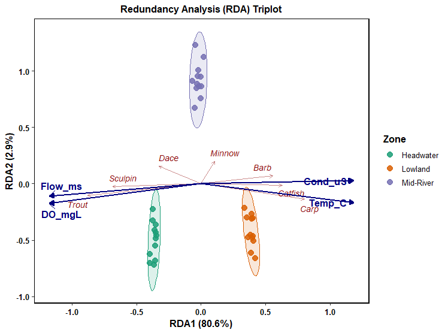

```r
res_rda <- rda_analysis(
  comm_data          = comm_survey,
  env_data           = env_survey,
  group_col          = "Zone",
  transform          = "hellinger",
  color_palette      = "Dark2",
  species_arrow_mult = 1.0,
  env_arrow_mult     = 1.2
)

# Render publication triplot
res_rda$Plot
```

### 1.15.4 Model Inspection and Numerical Summaries

The returned list provides the underlying `vegan::rda` object, global model permutation significance, and marginal variable significance:

```r
# 1. Global RDA Model Permutation Test (adonis/anova)
res_rda$Model_Significance
```

```
#> Permutation test for rda under reduced model
#> Permutation: free
#> Number of permutations: 999
#>
#> Model: rda(formula = comm_mat ~ Temp_C + DO_mgL + Flow_ms + Cond_uS, data = env_mat_scaled)
#>          Df Variance      F Pr(>F)
#> Model     4 0.268865 40.447  0.001 ***
#> Residual 31 0.051517
#> ---
#> Signif. codes:  0 '***' 0.001 '**' 0.01 '*' 0.05 '.' 0.1 ' ' 1
```

```r
# 2. Marginal Environmental Term Significance (unique partial effects)
res_rda$Variable_Significance
```

```
#> Permutation test for rda under reduced model
#> Marginal effects of terms
#> Permutation: free
#> Number of permutations: 999
#>
#> Model: rda(formula = comm_mat ~ Temp_C + DO_mgL + Flow_ms + Cond_uS, data = env_mat_scaled)
#>          Df Variance      F Pr(>F)
#> Temp_C    1 0.010027 6.0334  0.014 *
#> DO_mgL    1 0.005364 3.2277  0.066 .
#> Flow_ms   1 0.002476 1.4900  0.232
#> Cond_uS   1 0.002079 1.2511  0.271
#> Residual 31 0.051517
#> ---
#> Signif. codes:  0 '***' 0.001 '**' 0.01 '*' 0.05 '.' 0.1 ' ' 1
```

```r
# 3. Constrained vs Unconstrained Inertia Breakdown
summary(res_rda$RDA_Object)$tot.chi
```

```
#> [1] 0.3203818
```

```r
summary(res_rda$RDA_Object)$concont$importance[, 1:2]
```

```
#>                            RDA1        RDA2
#> Eigenvalue            0.2582838 0.009324137
#> Proportion Explained  0.9606456 0.034679644
#> Cumulative Proportion 0.9606456 0.995325281
```

## 1.16 Distance-based Redundancy Analysis (db-RDA)

The `dbrda_analysis()` function performs constrained ordination using non-Euclidean ecological distance metrics via Distance-based Redundancy Analysis (`vegan::dbrda`). Classical Redundancy Analysis (RDA) relies on Euclidean distances, which can lead to distortion when analyzing zero-skewed ecological abundance matrices.

### 1.16.1 Conceptual Framework and Mathematical Formulation

Let $\mathbf{D} = [d_{ij}]_{n \times n}$ denote an ecological distance matrix among $n$ sampling sites. The matrix $\mathbf{D}$ is centered via Gower’s centering transformation:

$$\mathbf{G} = -\frac{1}{2} \left(
\mathbf{I} - \frac{1}{n} \mathbf{11}^T \right) (\mathbf{D}^{(2)}) \left(
\mathbf{I} - \frac{1}{n} \mathbf{11}^T \right)$$

where $\mathbf{D}^{(2)} = [d_{ij}^2]$ is the matrix of squared dissimilarities.

Spectral decomposition of $\mathbf{G}$ produces eigenvalues $\boldsymbol{\Lambda}$ and eigenvectors $\mathbf{V}$:

$$\mathbf{G} = \mathbf{V}
\boldsymbol{\Lambda} \mathbf{V}^T$$

Principal coordinate vectors with positive eigenvalues $\mathbf{Z} = \mathbf{V}_+ \boldsymbol{\Lambda}_+^{1/2}$ represent the Euclidean embedding of the original dissimilarity matrix.

#### 1.16.1.1 Constrained Regression and Model Permutation

The coordinate matrix $\mathbf{Z}$ is regressed onto the standardized environmental predictor matrix $\mathbf{X}_{n \times m}$:

$$\hat{\mathbf{Z}} = \mathbf{X}
(\mathbf{X}^T \mathbf{X})^{-1} \mathbf{X}^T \mathbf{Z}$$

PCA is subsequently applied to $\hat{\mathbf{Z}}$ to construct the canonical axes ($\text{dbRDA}_1, \text{dbRDA}_2$). Overall model significance and the marginal contributions of individual environmental variables are evaluated through permutation testing (pseudo-$F$ tests with 999 Monte Carlo permutations):

$$F = \frac{\text{tr}(\hat{\mathbf{Z}}^T
\hat{\mathbf{Z}}) / m}{\text{tr}(\mathbf{E}^T \mathbf{E}) / (n - m -
1)}$$

where $\mathbf{E} = \mathbf{Z} - \hat{\mathbf{Z}}$ represents the residual matrix of unconstrained variation.

### 1.16.2 In-Vignette Data Generation

We simulate an estuarine benthic macroinvertebrate community across 36 stations classified into three Hydrological Zones (`Upper Estuary`, `Middle Basin`, `Outer Marine`). The community dataset is paired with four continuous sediment and water column metrics (Salinity, Total Organic Carbon, Silt Fraction, and Water Depth):

```r
set.seed(1414)
n_stations <- 12
zones <- c("Upper Estuary", "Middle Basin", "Outer Marine")

# Simulated environmental predictors
env_list <- lapply(zones, function(zn) {
  switch(zn,
    "Upper Estuary" = data.frame(
      Salinity_PSU = rnorm(n_stations, 8.5, 1.2),
      TOC_percent  = rnorm(n_stations, 4.2, 0.5),
      Silt_percent = rnorm(n_stations, 68, 6),
      Depth_m      = rnorm(n_stations, 3.5, 0.4)
    ),
    "Middle Basin"  = data.frame(
      Salinity_PSU = rnorm(n_stations, 18.0, 1.5),
      TOC_percent  = rnorm(n_stations, 2.6, 0.4),
      Silt_percent = rnorm(n_stations, 42, 5),
      Depth_m      = rnorm(n_stations, 8.2, 0.8)
    ),
    "Outer Marine"  = data.frame(
      Salinity_PSU = rnorm(n_stations, 32.5, 0.9),
      TOC_percent  = rnorm(n_stations, 1.1, 0.2),
      Silt_percent = rnorm(n_stations, 15, 3),
      Depth_m      = rnorm(n_stations, 18.5, 1.5)
    )
  )
})
env_estuary <- do.call(rbind, env_list)

# Simulated benthic community matrix (6 diagnostic taxa)
comm_list <- lapply(zones, function(zn) {
  means <- switch(zn,
    "Upper Estuary" = c(Oligochaeta = 42, Chironomidae = 35, Polychaeta_A = 6,  Bivalvia_A = 2,  Amphipoda_A = 4,  Decapoda_A = 0),
    "Middle Basin"  = c(Oligochaeta = 14, Chironomidae = 18, Polychaeta_A = 28, Bivalvia_A = 22, Amphipoda_A = 16, Decapoda_A = 5),
    "Outer Marine"  = c(Oligochaeta = 1,  Chironomidae = 0,  Polychaeta_A = 48, Bivalvia_A = 34, Amphipoda_A = 30, Decapoda_A = 18)
  )
  mat <- do.call(cbind, lapply(means, function(m) rpois(n_stations, lambda = m)))
  df <- as.data.frame(mat)
  df$Estuary_Zone <- zn
  df
})
comm_estuary <- do.call(rbind, comm_list)

# Set grouping metadata as first column
comm_estuary <- comm_estuary[, c("Estuary_Zone", setdiff(names(comm_estuary), "Estuary_Zone"))]

head(comm_estuary[, 1:6], 4)
```

```
#>    Estuary_Zone Oligochaeta Chironomidae Polychaeta_A Bivalvia_A Amphipoda_A
#> 1 Upper Estuary          45           32           11          0           3
#> 2 Upper Estuary          35           26            6          3          11
#> 3 Upper Estuary          38           29            4          1           1
#> 4 Upper Estuary          47           37            3          2           3
```

```r
head(env_estuary, 4)
```

```
#>   Salinity_PSU TOC_percent Silt_percent  Depth_m
#> 1     7.599730    3.919065     56.09989 3.218138
#> 2     8.395406    3.957087     79.05169 3.487593
#> 3     9.941565    3.902267     64.37852 3.872967
#> 4     8.293515    4.436544     50.99208 3.262603
```

### 1.16.3 Visualization Styles

#### 1.16.3.1 Style A: Bray-Curtis db-RDA Triplot (Default)

Computes Bray-Curtis dissimilarity, applies environmental scaling, and produces the publication triplot:

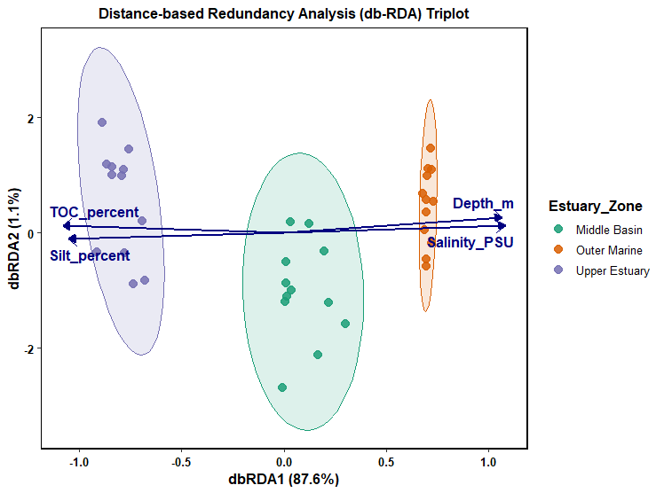

```r
res_dbrda <- dbrda_analysis(
  comm_data          = comm_estuary,
  env_data           = env_estuary,
  group_col          = "Estuary_Zone",
  dist_method        = "bray",
  transform          = "none",
  color_palette      = "Dark2",
  species_arrow_mult = 1.0,
  env_arrow_mult     = 1.1
)

# Render publication triplot
res_dbrda$Plot
```

### 1.16.4 Model Inspection and Numerical Summaries

The returned list provides the underlying `vegan::dbrda` model object, the global permutation significance test, and marginal term significance:

```r
# 1. Global db-RDA Permutation Test (adonis/anova)
res_dbrda$Model_Significance
```

```
#> Permutation test for dbrda under reduced model
#> Permutation: free
#> Number of permutations: 999
#>
#> Model: vegan::dbrda(formula = comm_mat ~ Salinity_PSU + TOC_percent + Silt_percent + Depth_m, data = env_mat_scaled, distance = dist_method)
#>          Df SumOfSqs    F Pr(>F)
#> Model     4   4.2675 60.5  0.001 ***
#> Residual 31   0.5467
#> ---
#> Signif. codes:  0 '***' 0.001 '**' 0.01 '*' 0.05 '.' 0.1 ' ' 1
```

```r
# 2. Marginal Environmental Predictor Significance (unique partial variance)
res_dbrda$Variable_Significance
```

```
#> Permutation test for dbrda under reduced model
#> Marginal effects of terms
#> Permutation: free
#> Number of permutations: 999
#>
#> Model: vegan::dbrda(formula = comm_mat ~ Salinity_PSU + TOC_percent + Silt_percent + Depth_m, data = env_mat_scaled, distance = dist_method)
#>              Df SumOfSqs       F Pr(>F)
#> Salinity_PSU  1  0.04813  2.7295  0.108
#> TOC_percent   1  0.12682  7.1919  0.012 *
#> Silt_percent  1 -0.00053 -0.0303  0.998
#> Depth_m       1  0.02884  1.6355  0.225
#> Residual     31  0.54666
#> ---
#> Signif. codes:  0 '***' 0.001 '**' 0.01 '*' 0.05 '.' 0.1 ' ' 1
```

```r
# 3. Constrained vs Unconstrained Variance Breakdown
summary(res_dbrda$dbRDA_Object)$tot.chi
```

```
#> [1] 4.814109
```

```r
summary(res_dbrda$dbRDA_Object)$concont$importance[, 1:2]
```

```
#>                          dbRDA1     dbRDA2
#> Eigenvalue            4.2176612 0.05124736
#> Proportion Explained  0.9883327 0.01200889
#> Cumulative Proportion 0.9883327 1.00034161
```

## 1.17 Hierarchical Clustering Dendrogram

The `cluster_dendrogram()` function performs agglomerative hierarchical cluster analysis (HCA) on ecological community abundance matrices or multi-parameter environmental datasets. While ordination approaches (e.g., NMDS, PCA, RDA) display continuous gradients across reduced orthogonal dimensions, hierarchical clustering groups sampling units into discrete nested clusters based on pairwise resemblance.

The function computes dissimilarity matrices using standard ecological distance metrics (e.g., Bray-Curtis, Jaccard, Euclidean), applies optional community transformations, conducts agglomerative clustering across user-selected linkage criteria (UPGMA, Ward’s minimum variance, Complete), and generates a native `ggplot2` tree diagram complete with color-coded group leaves, an optional cut-off threshold line, and sample cluster assignments.

### 1.17.1 Conceptual Framework and Mathematical Formulation

Let $\mathbf{Y}_{n \times p}$ denote a community matrix of $n$ sampling stations and $p$ aquatic taxa. Pairwise ecological dissimilarity $d_{ij}$ is computed using the Bray-Curtis metric:

$$d_{ij} = \frac{\sum_{k=1}^p |y_{ik} -
y_{jk}|}{\sum_{k=1}^p (y_{ik} + y_{jk})}$$

Agglomerative hierarchical clustering begins with each sampling unit treated as a single-element cluster ($C_i = \{i\}$). At each sequential step, the two clusters with the minimum inter-cluster distance are merged until all samples are unified into a single root node.

#### 1.17.1.1 Agglomerative Linkage Criteria

The definition of distance between two composite clusters $A$ and $B$ depends on the chosen linkage method:

1. Unweighted Pair-Group Method with Arithmetic Mean (UPGMA / `cluster_method = "average"`): Calculates the mean pairwise dissimilarity between all members of cluster $A$ and cluster $B$:
   $$D(A, B) =
   \frac{1}{|A| \cdot |B|} \sum_{i \in A} \sum_{j \in B} d_{ij}$$
   Preserves cophenetic correlation with minimal spatial distortion.
2. Ward’s Minimum Variance (`cluster_method = "ward.D2"`): Merges the cluster pair that minimizes the increase in total within-cluster error sum of squares (ESS):
   $$\Delta \text{ESS}_{AB} = \frac{|A|
   \cdot |B|}{|A| + |B|} \|\bar{\mathbf{y}}_A -
   \bar{\mathbf{y}}_B\|^2$$
   Tends to produce compact, spherical, and balanced cluster topologies.
3. Complete Linkage (`cluster_method = "complete"`): Defines distance as the maximum pairwise dissimilarity between clusters:
   $$D(A, B) = \max \{d_{ij} : i \in A, \, j \in
   B\}$$